# Emotions predict policy support: Why it matters how people feel about climate change - ScienceDirect

[figure not shown]

×

Skip to main contentSkip to article

[My account](https://www.sciencedirect.com/user/login?targetURL=%2Fscience%2Farticle%2Fpii%2FS095937801731004X&from=globalheader)

- [View **PDF**](https://www.sciencedirect.com/science/article/pii/S095937801731004X/pdfft?md5=73259dc0c9fd9c39f6270f0c9ce21ca9&pid=1-s2.0-S095937801731004X-main.pdf)

## [Global Environmental Change](https://www.sciencedirect.com/journal/global-environmental-change)

[Volume 50](https://www.sciencedirect.com/journal/global-environmental-change/vol/50/suppl/C), May 2018, Pages 25-40

# Emotions predict policy support: Why it matters how people feel about climate change

, [Zoe Leviston <sup>b</sup>](https://www.sciencedirect.com/author/24080850100/zoe-leviston), , , [Iain Walker <sup>c</sup>](https://www.sciencedirect.com/author/7201911066/iain-a-walker)

https://doi.org/10.1016/j.gloenvcha.2018.03.002[Get rights and content](https://s100.copyright.com/AppDispatchServlet?publisherName=ELS&contentID=S095937801731004X&orderBeanReset=true)

Full text access

## Highlights

- •

  This paper sheds light on *why* people feel specific, or any, emotions about [climate change](https://www.sciencedirect.com/topics/agricultural-and-biological-sciences/climate-change) and links these emotions to support for climate action.
- •

  We demonstrate a connection between objects of care, the emotions they evoke, and actions to address climate change.
- •

  Various emotion profiles may lead to different behavioural outcomes.
- •

  Climate communication efforts should focus messages on things that people care about, and appeal to different self-conceptions and identities.

## Abstract

Current research shows that emotions can motivate climate engagement and action, but precisely how has received scant attention. We propose that strong emotional responses to climate change result from perceiving one’s “objects of care” as threatened by climate change, which motivates caring about climate change itself, and in turn predicts behaviour. In two studies, we find that climate scientists (N = 44) experience greater emotional intensity about climate change than do students (N = 94) and the general population (N = 205), and that patterns of emotional responses explain differences in support for climate change policy. Scientists tied their emotional responses to concern about consequences of climate change to future generations and the planet, as well as personal identities associated with responsibility to act. Our findings suggest that “objects of care” that link people to climate change may be crucial to understanding why some people feel more strongly about the issue than others, and how emotions can prompt action.

- [Previous article in issue](https://www.sciencedirect.com/science/article/pii/S0959378017311809)
- [Next article in issue](https://www.sciencedirect.com/science/article/pii/S0959378017310506)

## Keywords

Climate change

Emotion

Care

Identity

Field theory

Psychological distance

## 1. Introduction

The psychological study of [climate change](https://www.sciencedirect.com/topics/agricultural-and-biological-sciences/climate-change) has progressed toward answering some major questions, such as why some accept and some deny the existence or severity of climate change, what barriers prevent action, and how to frame the issue to encourage acceptance and action. We now understand many reasons why people may not consider climate change a serious problem, and may not act. These range from limited cognitions that evolved from a different time, to factors involving trust, risk, social norms, and perceived efficacy of action (Gifford, 2011). There is also an extensive literature around the individual factors that predict climate change action, such as environmental values (Steg and Vlek, 2009; Van der Werff et al., 2014), and traits such as self-transcendence and connectedness to nature (Gifford and Nilsson, 2014; Cheung et al., 2014; Brügger et al., 2011), which touch on feelings of closeness to the planet. Through this research, we have come to understand some of the social, cognitive, and behavioural aspects of climate change. However, the precise role emotions play in understanding responses to climate change has received relatively little attention (Roeser, 2012).

Over time, awareness of climate change has increased. More than ever, people think that climate change is happening now, and will affect people and places near them, but emotional responses such as worry and concern remain low (Steentjes et al., 2017). Greater recognition of the role of emotions will help us understand not only how climate change is perceived by individuals, but also other interactions around climate change where emotions play a role: in activist groups and [collective action](https://www.sciencedirect.com/topics/agricultural-and-biological-sciences/collective-action) movements (Harth et al., 2013), anti-climate change demonstrations, in climate change denial and avoidance (Norgaard, 2006), and in portrayals in media (O’Neill and Nicholson-Cole, 2009).

Current research shows that emotions such as anger, fear, and guilt can motivate climate change action (Bamberg and Möser, 2007; Bissing-Olson et al., 2016; Ferguson and Branscombe, 2010; Harth et al., 2013; Lu and Schuldt, 2016; Mallett et al., 2013; Rees et al., 2015). From this, two inferences have been made: 1) that those who care about climate change feel such emotions, and 2) inducing these emotions will elicit climate change action in other individuals. These inferences form the basis for interventions designed to emotionally appeal to the public. However, we suggest that groundwork for these inferences is under-developed. First, we know of no studies that have focused directly on people who care about climate change, or defined what it might mean to care about climate change. Second, there is little information about *why* people feel specific, or any, emotions about climate change.

### 1.1. To care about climate change

Little is known about what it means to “care about climate change”, possibly because it is difficult to define what caring means here. The verb “to care” has three relevant meanings in this context: to attach interest or importance to the object of care; to feel emotions such as anxiety or affection toward it; and to protect or safeguard it (i.e., to care *for* something).

Here, “climate change” is not the object of care, because it is not an object of affection, or a thing to be protected. Rather, it is a threat to things about which we care. To care about climate change is paradoxically not about climate change itself, but about the things that it will harm or take away from us. A similar idea has been put forth in research on environmental movements (Stern et al., 1999) and the consequences of environmental loss (Brügger et al., 2015; Albrecht et al., 2007), where implications for valued objects, or “objects of care”, are central to understanding human responses to environmental decline.

If we accept this interpretation of what it means to care about climate change, these objects of care could be viewed as connectors, ones that make the issue of climate change seem personally relevant to the individual.

The idea of “connectors”, introduced in ecological psychology, describes the influences on an individual in spatial terms. Lewin (1951) theorised that the individual can be understood as a function of spatial maps representing their entire physical, social, and inner mental environments. Within this framework, any entity that can influence the individual (e.g., a person, place, value, goal, or event) is represented as a region of space. All these regions can not only affect the individual, they can affect each other too. For instance, if we look at the spatial environment of a person who has a child, the child can be understood as a region of influence that can affect the individual’s thoughts and actions (Lewin, 1951). If the region “child” is perceived to be threatened by another region “climate change” then this may influence the individual’s thoughts and actions. As another example, a person may have a close attachment to a social or ideological group, and if this group is concerned about climate change, the group may serve to bring the issue closer to the individual. Yet another example is a person influenced by strong core values that are perceived to be threatened by climate change. By connecting the self to climate change, objects of care may bring the issue of climate change closer.

As implied by the term “bring closer”, each region may be located psychologically close to, or distantly from the individual, and these distances can change. Lewin used the term “locomotion” to describe the various interactions that regions may have with one another (Lewin, 1936). For instance, an “approach” interaction may reduce distance, while an “avoid” interaction increases distance. In the previous example, a parent may experience an approach response to “climate change” to protect their child, whereas a person without children may not. As will become clear next, these concepts are important to understanding why people care about climate change.

### 1.2. Psychological distance

Psychological distance – an indicator of how close or distant people feel from a particular object, event, or person – is of growing importance to climate change research, in part because in many studies, people report feeling distant from the impacts of climate change, and perceive that they will be largely unaffected (Howe et al., 2015; Leiserowitz, 2005; Spence et al., 2012; Steentjes et al., 2017). Correlational studies have shown that psychological distance relates negatively to pro-environmental action (Spence et al., 2012; Mcdonald et al., 2015), and consequently, several studies have tested interventions crafted to bring climate change closer to the individual – but the results of such studies have been mixed (Brügger et al., 2015; Mcdonald et al., 2015; Mcdonald et al., 2013; Scannell and Gifford, 2011; Spence and Pidgeon, 2010).

One reason for the mixed results may be the operationalisation of psychological distance in the context of bringing climate change closer. Psychological distance is typically measured through perceptions of personal risk from climate change, such as when and where it will occur, the likelihood with which it will occur, and who will be affected by it (Spence et al., 2012; Brügger, 2013). The argument is that proximatising climate change can make the issue seem more personally relevant, and more emotionally evocative (Brügger et al., 2015; Mcdonald et al., 2015).

However, this approach to reduce psychological distance assumes that the “self” and those people and places near to it are the only objects of care; climate change is close if people perceive themselves to be affected by it, or distant if they do not. This method only captures one reason for engaging with climate change. For this reason, it has been critiqued for presuming that proximity to self is necessary – and all that is necessary – to care about climate change (see Devine-Wright, 2013, for a discussion).

The psychological distance concept can be more broadly useful to explain the relationships between objects of care and the self. According to Lewin (1936), emotions such as fear, hope, and guilt serve as guides for behaviour, they are triggered by objects that shape the structure of one’s internal spatial environment. Fear, for instance, is an aversive response to the perception of an undesirable psychological future. “Objects of care” that appear threatened by climate change may trigger such emotional responses.

Only a handful of studies have looked at emotion as a part of psychological distance (Brügger, 2013; Van Boven et al., 2010; Hackenbracht and Gasper, 2013; Davis et al., 2011). Objects and people that are psychologically close to us elicit stronger emotions than those that are distant (Hackenbracht and Gasper, 2013), and conversely, feeling strong emotions can reduce perceptions of psychological distance from an object or event (Van Boven et al., 2010). In the context of climate change, reducing distance can, by increasing risk perceptions, have similar consequences on behavioural intentions as manipulating negative emotion (fear) (Brügger, 2013). And while proximatising climate change can lead to greater emotional responses, the effect is reversed too: distancing oneself from climate change is thought to be a coping mechanism for potentially overwhelming feelings (Caillaud et al., 2015; Ojala, 2012a; Norgaard, 2006; Dickinson, 2009).

For many people, climate change is a threat that is happening now, and yet it remains a distant issue emotionally (Steentjes et al., 2017). With a broader understanding of psychological distance, we can begin to understand why this might be the case.

### 1.3. Emotions and caring about climate change

Emotions tend to have a motivating effect on climate-relevant behaviour. The experience of negative affect relates to self-reported pro-environmental behaviours (Leviston and Walker, 2012), and climate change policy support (Leiserowitz, 2006; Smith and Leiserowitz, 2014). Even the incidental occurrence of emotions – emotions triggered by events unrelated to climate change – can influence mitigation policy preferences (Lu and Schuldt, 2015). Notably, the relationship between emotions and climate change action is not consistent in all contexts, particularly those that attempt to induce the former to produce the latter. For instance, some research suggests that negative emotions enhance perceptions of risk (Slovic et al., 2004), and greater perceptions of risk from climate change may then lead to increased action motivation. However, fear appeals—persuasive messages that stir negative emotions—can sometimes be counterproductive (O’Neill and Nicholson-Cole, 2009). Similarly, messages of hope have been found to increase action in some cases (Myers et al., 2012; Ojala, 2012b) and reduce it in others by lowering risk perceptions (Hornsey and Fielding, 2016).

As Chapman et al. (2017) argue, such approaches tend to treat emotions as a lever, where pulling the correct one will produce the desired behaviour. There is a level of complexity in emotional responses that cannot be captured without looking in detail at the triggers for these emotions, the objects that cause these emotions to arise. For instance, during the Copenhagen Climate Summit, a representative of Tuvalu unexpectedly introduced emotion into his formal address, expressing intense sadness about the state of negotiations and the fate of his nation (Farbotko and McGregor, 2010). The anticipated loss of a valued place or entity, such as one’s nation, may be a critical trigger for emotion, and negative emotion in particular has the function of rectifying or acting to avoid adverse consequences (Keltner and Lerner, 2010).

A considerable body of work exists on triggers for emotions, mainly within appraisal-theoretical models of emotion, and particularly in perceptions of environmental risk (Keller et al., 2012; Böhm and Pfister, 2000). These approaches stem from the argument that emotions are about something or someone, and arise when an event is relevant for one’s values and concerns (Zeelenberg et al., 2008). Böhm and Pfister have extensively examined how the relationship between cognitions and behaviour toward environmental risks are mediated by emotional evaluations, showing that two particular cognitive appraisals, one concerning the anticipation of negative consequences and loss, and one concerning whether ethical and moral principles have been violated, relate to different emotional and behavioural outcomes (Böhm and Pfister, 2017; Pfister and Böhm, 2008; Böhm, 2003; Böhm and Pfister, 2000). These approaches inform and are compatible with the concept of “objects of care”, following the same premise, that perceptions of risk or threat to valued objects lead to emotional, and behavioural responses.

The advantage of such approaches is the ability to explain why individuals respond differently to the same environmental threats (Smith and Kirby, 2009). In one study, Böhm and Pfister (2017) focused specifically on whether identities affect one’s appraisals of environmental risk, in a study that asked participants to adopt the perspective of different roles (a mayor, a parent, and an environmental activist). While the effects of social role on appraisals were not strong, the authors recommend future work that looks in detail at those who possess such identities – an aim of the present study.

Since most research in this area are surveys or experiments which constrain responses, they may not accurately reflect how people spontaneously understand, or misunderstand climate change, nor the competing influences on affective responses to climate change. The value of qualitative analyses in this context lies in the ability to view the emotions and cognitions that people express in a bottom-up manner, that does not constrain responses. There is also the opportunity to see how people understand and misunderstand the issue, and the often competing reasons underlying affective responses to climate change (Wolf and Moser, 2011).

Perhaps the most extensive qualitative work on climate change emotions was conducted by Fischer et al. (2012), who interviewed residents in five European nations, studying social representations of energy production and consumption. They found that affective responses to climate change were a recurrent theme. The most common emotions were concern and worry, used interchangeably, and motivated by anticipated harm to children and grandchildren (Fischer et al., 2012). Other emotions, such as confusion, resignation, and powerlessness, were mentioned alongside perceptions of low individual efficacy.

Interviews of Norwegian adults also found that low efficacy and negative emotions characterised responses to climate change (Norgaard, 2006). Participants described fears associated with a loss of ontological security (helplessness and uncertainty about the future, and how life would continue). They also expressed guilt for residing in a rich nation that has benefited from [fossil fuels](https://www.sciencedirect.com/topics/agricultural-and-biological-sciences/fossil-fuel); this was perceived as a threat to their Norwegian identity as good, socially just people. It appears that climate change threatened their notions of the future and of themselves, but the need to act was countered by a low sense of efficacy.

There have also been studies of groups who may have atypical experiences of climate change. For instance, Lefsrud and Meyer (2012) studied the discursive construction of climate change from the perspective of scientists and engineers working in the petroleum industry. The most emotionally expressive group were those who felt their identities as experts most threatened, and felt that action on climate change would be more detrimental than inaction because of feared effects on the economy. These emotions can be interpreted as responses to the perception of threat to various objects of care: their identities, and economic wellbeing. The responses to such threats were expressed in emotional, figurative language, and there was an “approach” tendency, or a “call to arms” to encourage protests.

Another [case study](https://www.sciencedirect.com/topics/agricultural-and-biological-sciences/case-study) looked at villagers in Tibet (Byg and Salick, 2009). To the villagers, climate change caused anxiety and worry, its meaning entwined with numerous spiritual beliefs about the world and nature. These emotions were associated with the loss of natural beauty, the destruction of humans and the Earth, and frustration about suffering from the actions of others, from a situation that is largely out of their control.

The qualitative studies reviewed above suggest that factors such as attachment to nature, threat to self-identity, and anticipated harm to future generations, may be objects of care that link various groups to climate change, however, none explicitly sought to identify objects that lead people to care about climate change. Further, they did not specifically sample people who cared about climate change. The aforementioned studies have looked closely at reactions from occupational groups, national groups, and others have focused specifically on teachers (Lombardi and Sinatra 2013), and young people (Strazdins and Skeat, 2011), however, to understand the emotions of those who care about climate change, and why they care, we need to look at different samples.

It is difficult to ascertain which groups are best to study *a priori*, but there are several feasible populations: people who have personally experienced the effects of climate change, climate change activists, and climate scientists. It is reasonable to think that active engagement with climate change, of the kind experienced by members of these groups, may represent emotional and psychological closeness to the issue. Such engagement may have led to development of a richer, more nuanced set of emotional responses. By focusing on such a group, we can explore their emotional reactions to climate change, why they are emotionally close and what that looks like.

Climate scientists are an important group to study, partly because the scientific consensus is a persistent issue of social confusion (Steentjes et al., 2017), but also because scientists are important messengers in climate change communication. Recent projects have highlighted the emotional responses of climate scientists as a way of engaging people with climate change (Climate Council, 2016; Duggan, 2015). One example is the “Is This How You Feel?” Project (ITHYF), which asks climate scientists from around the world to write letters about how they feel about climate change (Duggan, 2015). Duggan’s project is unique in that it asks a group of people who are occupationally close to climate change to explain how they *feel* about the issue, rather than what they think.

We explore *why* people feel emotions about climate change by comparing the qualitative responses of climate scientists from the ITHYF project with that of university students (Study 1) and a general population sample (Study 2), as research to date typically focuses on the latter two samples. With the premise that caring about climate change is linked to perceiving threat to one’s objects of care, we explore the emotional reactions to climate change in all three samples, and any connection with objects of care. Aside from replicating qualitative findings in a wider context, Study 2 also asked whether these emotions predict support for climate policy.

## 2. Study 1

The first study examined responses from climate scientists using data collected externally by the ITHYF project, in addition to responses from a new survey conducted by the current authors, asking students to report their feelings about [climate change](https://www.sciencedirect.com/topics/agricultural-and-biological-sciences/climate-change).

### 2.1. Method

The scientist data (*N* = 44) were collected from the ITHYF website ([www.isthishowyoufeel.com](http://www.isthishowyoufeel.com/)), where it is freely accessible. Scientists were approached through individual emails. They were asked to write a letter addressing the question “How do you feel about climate change?”—with a focus on the emotions they feel toward climate change—for the purposes of science communication (more detail in Supplementary Material). The student data were collected from a sample (*N* = 94, 60% female, mean age = 20 years) of psychology students at the University of Western Australia, remunerated with course credit. The students were asked to “Please write a few sentences in response to the following question: How do you *feel* about climate change?”, and additionally answered questions about rainfall in Western Australia for a separate study.

The initial analysis involved open coding of both student and scientist text, using RQDA, a package for qualitative analysis available through the R open-source software (Huang, 2016). The method draws upon the constructivist version of Grounded Theory and axial coding (Strauss and Corbin, 1998; Charmaz, 2014). We began with open coding (coding words or phrases found in text), and axial coding (creating themes or categories by grouping codes) and constant comparison of data. Codes were generated inductively and included codes relating to climate change belief, climate change consequences, emotions, as well as references to spatial, social and temporal relationships. To triangulate across analytic methods, the data were also simultaneously analysed using Leximancer software. Leximancer differs from other programs that facilitate qualitative research, such as NVivo, in that it employs algorithms to detect main ideas from a corpus of text and calculates relationships between ideas. The themes extracted by Leximancer, and the results from open coding were used as a guide for a content analysis using Grounded Theory. For a more detailed discussion of the Leximancer analysis, see Supplementary Material

### 2.2. Results

The codes of highest frequency are shown in Table 1 (data for Study 2 are also shown for later reference). For students, the most frequent responses were: “I think”, denoting statements about the existence and attributions of climate change; “lack knowledge”, about needing more information about climate change; and “action”, about the need to act on climate change. The most frequent responses from scientists were: “optimism” about addressing climate change; “global”, a reference to the planet; “future generations”; and a wide range of emotions (a full list of codes can be found in Supplementary Material).

Table 1. Most frequent tags for each sample.

| Top tags | Study 1 Students (No.) | Study 1 Empty Cell | Study 1 Scientists (No.) | Study 1 Empty Cell | Study 2 General population (No.) | Study 2 General population (No.) |
| --- | --- | --- | --- | --- | --- | --- |
| 1 | “I think” | 55 | hope | 21 | “I think” | 60 |
| 2 | lack knowledge | 24 | the world/planet/Earth | 20 | worried | 33 |
| 3 | pro-environmental action | 18 | future generations | 19 | future generations | 25 |
| 4 | humanity | 15 | humanity | 17 | natural causes | 24 |
| 5 | climate consequences | 15 | frustrated | 16 | the government | 21 |
| 6 | natural causes | 13 | close relationships | 13 | sceptic | 14 |
| 7 | future generations | 12 | climate consequences | 13 | “my issue”† | 14 |
| 8 | urgency | 10 | responsibility | 13 | agenda | 12 |

**†**

A few codes were newly introduced in the general population sample, as they had not arisen in the two samples in Study 1. “My issue” was used to encode responses where the respondent used the outlet to voice their concern for an issue besides climate change, such as: corporate donations to political parties, population growth, religious fanaticism, etc.

Fig. 1, Fig. 2 show content maps illustrating the themes auto-extracted by Leximancer. Scientist responses are spatially distant from the student responses. The scientist responses are also separately positioned, not encompassed by any other theme, whereas the student responses are placed within the “happening” theme, suggesting that terms such as “happening”, and nearby terms “believe”, “real”, dominate student responses. Another difference can be seen in connections denoted by red lines in Fig. 2, between the source of the text (scientist or student), and the topic of discussion (e.g. children): the key difference is the lack of connection between the students and the concepts relating to emotion.

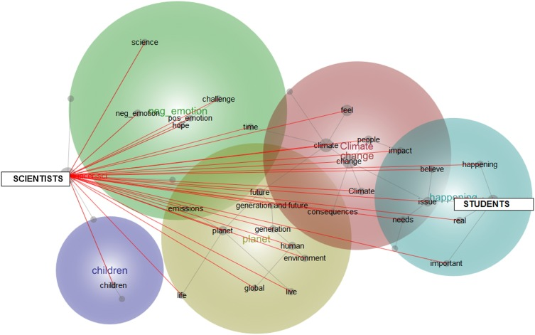

1. [Download: Download high-res image (530KB)](https://ars.els-cdn.com/content/image/1-s2.0-S095937801731004X-gr1_lrg.jpg)
2. [Download: Download full-size image](https://ars.els-cdn.com/content/image/1-s2.0-S095937801731004X-gr1.jpg)

Fig. 1. Concept map of scientist responses: direct mentions of concepts by scientists are indicated by red connections. Concepts are denoted by grey nodes, and they are connected by grey lines, which refer to strong connections between concepts. The size of the grey nodes indicates the frequency of the node. Themes (concepts that encompass many other concepts) are indicated by coloured text, located within coloured circles. The warmth of the colour of the circles denotes the centrality of a theme to the entire text (warm to cool = red, yellow, green, blue, purple). (For interpretation of the references to colour in this figure caption, the reader is referred to the web version of this article).

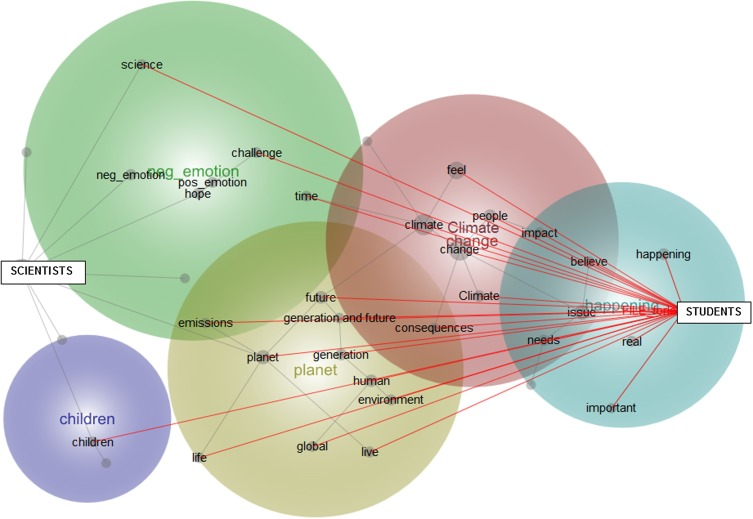

1. [Download: Download high-res image (552KB)](https://ars.els-cdn.com/content/image/1-s2.0-S095937801731004X-gr2_lrg.jpg)
2. [Download: Download full-size image](https://ars.els-cdn.com/content/image/1-s2.0-S095937801731004X-gr2.jpg)

Fig. 2. Concept map of student responses: mentions of concepts by students are indicated by red lines.

#### 2.2.1. Analysis of scientist responses

The scientist responses were run through Leximancer in the same manner as described for the entire sample. Themes were automatically extracted, and then examined in greater detail. As Leximancer does not analyse the meaning of the words used, subsequent analyses were conducted manually to investigate the contextual meaning of word use. We took each theme extracted by Leximancer, and listed each mention of those words and their surrounding context from the original text, resulting in a document structured according to the themes. The extracted texts were examined for consistency within themes, and overlap between themes, as well as irrelevance or erroneous classification. There was strong correspondence between the final themes and those from the initial open coding.

##### 2.2.1.1. Emotions about climate change

Most scientists referred to a multiplicity of emotions, “*So, what do I feel about climate change? Interest, intellectual curiosity, satisfaction, excitement, extreme worry, sadness, fear and perhaps a glimmer of hope*.”, and describe feeling conflicted, “*I feel nervous. I get worried and anxious, but also a little curious. The curiosity is a strange, paradoxical feeling that I sometimes feel guilty about*”. The emotional reactions were related to mentions of climate change as a challenge, for instance, confusion or frustration about the lack of acceptance of scientific evidence: “*Why do I feel bemusement? Because the scientific case is clear*”, and dislike of what was perceived to be the role of scientists: “*What motivated me to become a scientist in the first place was my desire to explain and model things we did not understand. It was never about preaching to others about an existing scientific consensus. I feel uncomfortable in this strange role nearly as much as I am in discussing about believing or not in climate change*”.

As for the wider challenge of addressing climate change, multiple emotions were evoked, some negative, “*I often feel compelled to be outraged by our own inability as a species to respond to the challenge climate change poses*”, and some positive, “*I am hopeful that we can solve the climate problem. It is a huge challenge because it requires international collaboration, and for people to act on behalf of others*”.

##### 2.2.1.2. Hope and humanity

This theme was characterised by the connection between two concepts, hope and the perception of humans. Many scientists referred to themselves as optimists, and expressed faith in humanity as reason for their hope, “*But, I also have a sense of hope. Humanity has shown throughout history that we can solve our problems*”. These statements expressed the view that climate change can be successfully addressed, and tended to be positioned at the end of responses, to end on a positive note.

Whether “hope” was mentioned depended on whether the view of humans was positive or negative. When the view of humans was positive, there was optimism, and when the view of humans was negative, there was pessimism: “*We* *face* *a problem that could be addressed with relatively minor shared sacrifices, but instead there is a mass effort to ignore, defer, deny, and lie… Global warming doesn’t bother me as much as what it is revealing about humans*”. A negative view of humans was associated not with hope, but “*Despair: humans are incredibly dumb. We find it very hard to think beyond me, here and now. Yet our task is to fix a generation of problems that are global and centennial – to learn and share a finite planet*”.

##### 2.2.1.3. Human-earth relationship

The third theme was called “Human-Earth relationship”, because use of the terms “world” or “planet” referred to relationships between humans and the Earth. Some concretised closeness to the Earth using anthropomorphic metaphors for friendship, “*How can anyone not feel an overwhelming sense of care and responsibility when those so dear to us are so desperately ill*?”, or as a doctor to a patient, “*Imagine how a medical doctor feels having to inform their patient, an old, life-long friend, of a dire but treatable diagnosis… …There is a similar closeness between climate scientists and the planet. There’s a sense of wonder and respect*”. In some cases, identities were used to explain their relationship to the Earth, “*we grew up with the concept of being stewards of the land and we care about the future abilities of farmers to be able to feed the world*”, “.

Scientists alternately described a nurturing relationship between humans and the Earth, and the ways in which humans have mistreated the Earth. “*How can you ignore the severe sickness of someone you are so intricately connected to and dependent upon?”*, “*Our biodiversity is our life* *[support system](https://www.sciencedirect.com/topics/agricultural-and-biological-sciences/support-system)**, each species a precious support system, each species a precious, irreplaceable heritage item*”, statements of nurture are juxtaposed with how humans have not reciprocated, “*We have harvested and cleared and plundered and spoiled*”, “*We humans are fouling our own nest, so to speak*”. Also present were visions and hope for a better relationship in future, “*I am not yet willing to give up on a future where humans live lightly upon the planet*”.

##### 2.2.1.4. Future generations

Scientists often referred to “future generations” (interspersed with the terms “children” or “grandchildren”) in their responses, with a narrative of loss and responsibility. There was a strong connection between the emotions and care for future generations. The responses referred to future generations experiencing loss, “*most of all I feel so very sorry for my children’s and my (hypothetical) grandchildren’s generation, for all the beautiful things in the world that they will miss*”, “*looking at my children and realizing that they won't have the same* *[quality of life](https://www.sciencedirect.com/topics/psychology/quality-of-life)* *we had*”. This loss was coupled with statements about responsibility, relating either to the notion that one ought to care for one’s children, “*What world are we leaving to our children and grandchildren?*”, or to the notion that climate change is this generation’s problem, “*As a human-being, and especially as a parent, I feel concerned that we are doing damage to the planet, I don’t want to leave a mess for my children, or anyone else’s children, to clear-up*”.

##### 2.2.1.5. Identities

Scientists discussed a variety of identities in each of the aforementioned themes, speaking not only “as scientists”, but as parents, as citizens, humans, people of their generation, and as messengers (whose responsibility it is to relay the message about climate change to others). “*I also consider it my duty* *as a scientist* *and* *as a citizen* *to try to inform the public and policy makers clearly about the predicament we are in and the choices we cannot avoid*”, “*I don’t want to become the* *generation* *that future children talk of as having destroyed the planet. I’d like to be the generation that fought back (and won) against human induced climate change*” (for more examples, see Supplementary Materials). Perhaps due to different terms being used to denote each identity, such a theme did not emerge from the Leximancer analysis.

#### 2.2.2. Analysis of student responses

##### 2.2.2.1. Belief in climate change

The first theme concerned students’ beliefs about climate change. Despite being asked about their *feelings* towards climate change, most respondents began responses by stating their opinions, “*I feel that climate change is a real, major issue that needs to be addressed now before it’s too late*”. Although none expressed the view that climate change was not real, there was low concern, “*maybe its because im selfish, i would not go too much out of my way to help make a change as i do not think the effects will have much of an effect on me in my lifetime*”, and scepticism, “*I do not feel as though it is an issue of great concern and I also feel as though claims that climate change will completely change how we live as humans is completely false*”.

Statements about whether climate change was real were often followed by whether the cause was natural or anthropogenic. Many statements referred to climate change being in part a natural process, “*I feel that it is happening and that humans should definitely attempt to reduce it. Of course in some ways, I believe climate change is natural and although humans are simply helping to speed up the process, climate change would still happen regardless if humans existed or not*”. Those who attributed climate change to anthropogenic causes tended to blame others, “*I feel that it is real and that it is happening right now largely due to the irresponsible actions of humans (mostly large corporations and some governments) over the past few decades*”, or abstract, systemic sources such as modern lifestyles, “*a lot of it is also due to how we engage in our activities (with such a fast-paced lifestyle, constant stress due to work, the need to travel. These things are hard to offset due to the nature of how life works now)*”. Responses also echoed scepticism from popular rhetoric such as “*we need more research to know for sure about climate change*”, and wariness of coercion, “*I am not sceptical of climate change itself, only wary that it is a highly emotive topic whose importance has the potential to become overly inflated by political agenda and popular beliefs. I do think further research should be made towards climate change so that opinions can be formed based on quantitative results*.”

##### 2.2.2.2. Future generations

Students tended to perceive climate change as a problem for the future, coupled with suggestions that other issues are of more immediate concern, “…*because the effects of climate change are only just starting to show, as this is a very early stage*”. Students indicated that future generations would be affected. Some used similar terms as scientists – referring to future generations as children, or as members of their group, “*I see it as being pretty unfair to have our future children deal with the problems we left them*”, “*it will affect the future well-being of us and the next generation*”. Others referred to future generations as an outgroup, “*it is imperative to educate the future generation about the importance of looking after the earth*”, “*awareness about climate change needs to be spread to the younger generation*”.

##### 2.2.2.3. Feel

While emotion was absent from most student responses, some did reference fear. “*It is happening and terrifying*”, and for some, fear seemed debilitating, “*I am scared of the outcomes of climate change. Especially due to the way it does not seem to be a priority problem for most people. I feel like I should do as much as possible to reduce my waste, energy and water use, but I often try it hard not to let the thought of climate change become too overwhelming big and that I cannot change anything*”.

##### 2.2.2.4. Action

Many responses discussed how climate change ought to be addressed. As individuals, students were not empowered to act, “*its a major problem and I would like to be part of the solution but I do not know how*”, corresponding with the “lack knowledge” theme that arose from open coding. Students thought that action should be taken as a collective, “*I think that each individual should change their lifestyle a little bit to reduce waste…*”. Another frequent response was “othering”, where responsibility for, and the impact of acting was attributed to governments and large organisations, “*it is most important that it is addressed at the level of government and industry. Individuals can help but legislation could have a larger impact*”, “*it is better to focus on the big companies that have much larger carbon footprints*”.

### 2.3. Discussion

The aim of Study 1 was to explore content analysis of emotional responses to climate change in two specific groups, climate scientists and students. The findings suggest important differences in the emotional experience of climate change. The high presence of emotional content in the scientist sample compared to the student sample was expected. Hope, anger, and frustration were the most commonly expressed emotions by scientists, whereas themes arising from the student sample showed a general lack of emotion. For students, the focus was more cognitive than emotional, such as whether they believed it was happening, whether humans were responsible, who would be affected, and who should act. Contemplating one’s belief about climate change may be superficial but necessary before any further considerations about climate change are possible. Another possibility is that we were not explicit enough about the request for emotional responses. Students may have interpreted the word “feel” as a request for thoughts and opinions. By contrast, scientists were given a clearer request for emotional responses. This potential limitation will be addressed in Study 2.

Interestingly, the topics discussed by students can be seen as more directly related to climate change than the topics discussed by scientists. The pragmatics of action and concerns about the impact and reality of climate change are directly related to climate change as an issue. However, for students, there was little connection between climate change and other issues, whereas topics raised by scientists were less about climate change than about the things *affected* by climate change (children, the planet, humanity). For scientists, climate change had broader connectivity to other areas of life.

This supports the conceptualisation of “caring about climate change” proposed in the Introduction, that one’s care for objects affected by climate change is central to caring about climate change itself. There were strong references in the scientist responses to close relationships; two themes describe close relationships to entities (the planet and future generations) adversely affected by climate change. For scientists, caring about those entities may then lead to caring about climate change, or vice versa. The close relationships to the planet and to future generations may be connectors to a sense of closeness to climate change, because they link the self to climate change.

Further, for scientists, climate change permeated multiple self-identities, had broader connectivity with other aspects of the self, and these identities were tied to emotional reactions to climate change. The challenge posed by climate change prompted scientists to refer to a personal identity, a parental identity, a collective human identity, a scientist identity, and a messenger identity. These identities were also tied to different, often conflicting emotions, as scientists (curiosity) or as parents (worry, fear). Responsibility to act was linked to role-based relationships, as friends, stewards, and as a doctor to a patient. On the other hand, students made little reference to themselves or their identities, and this suggests that climate change is disconnected from their self-conception.

## 3. Study 2

In Study 2, we were interested in establishing whether emotional responses similar to those elicited by scientists would be present in the general population, and whether those responses predict climate change action. With these considerations in mind, Study 2 included both qualitative and quantitative questions about climate change emotions, and measures of climate change policy support. We also addressed a potential methodological limitation from Study 1, clarifying instructions to emphasise that we were interested in emotional responses to climate change.

Findings from Study 1 suggest that no single emotion dominates scientists’ emotional responses, but rather, many emotions are involved. This supports some perspectives in emotion research (Chapman et al., 2017; Zeelenberg et al., 2008) – to study individual emotions separately is to view an incomplete picture. Fernando et al. (2014) found that the combined experience of anger and shame, as well as sympathy with a victimised group constitute a “strong pro-social emotion” response that strongly predicts [collective action](https://www.sciencedirect.com/topics/agricultural-and-biological-sciences/collective-action) to remedy intergroup inequality.

It is possible that the interplay of several emotions, which tends to reflect the actual experience of emotion, provides a better understanding of how emotions and behaviour relate. The emotion profile method developed by Siemer et al. (2007), applied to the collective action setting (Fernando et al., 2014), uses hierarchical clustering to identify groups of participants who respond similarly to one another. We used this method in Study 2 to identify different types of emotional responses to climate change (e.g. one group might experience high anger, and low guilt; another the reverse) so that each type is an “emotion profile” of how people respond emotionally to climate change. To the authors’ knowledge, this will be the first use of emotion profiles in the context of climate change action.

Study 2 examined the experience of emotions about climate change in two ways: firstly, by replicating the previous method used with the scientist and student samples, and comparing these with how a sample from the general population feels about climate change; and secondly, by identifying different profiles of emotions and testing whether these profiles predicted climate change action.

### 3.1. Method

A general sample of 205 participants in the Sydney area was recruited for Study 2 using Qualtrics Panels. The sample was roughly representative of the general Australian population by age and gender, with moderate deviations in the “25–54” and “65+” age categories (Table 2).

Table 2. Sampled Distribution Compared to Australian Population.

| Empty Cell | Empty Cell | Sample (%) | Population (%)* |
| --- | --- | --- | --- |
| Sex | Female | 50.73 | 50.70 |
|  | Male | 49.27 | 49.30 |
| Age | 18-24 | 11.71 | 12.29 |
|  | 25-54 | 66.34 | 53.38 |
|  | 55-64 | 12.68 | 14.74 |
|  | 65+ | 9.27 | 19.09 |

Population data were obtained from the Australian Bureau of Statistics (2014).

****

Data has been corrected to exclude the population under 18 years.

Participants were asked an open-ended question about their feelings and emotions about climate change. The instructions made clear that we were asking about emotions: “*We are interested in your* **feelings** *and* **emotions** *towards climate change. Your response can be any length, from a few lines to several paragraphs. There are no correct answers, please write about the emotions (if any) you feel when you think about climate change. How do you feel about climate change?*”.

Participants were then asked to indicate how strongly they experienced a series of emotions when thinking about climate change. The emotions were rated along a 5-point scale from 1 = Not at all, to 5 = Strongly (the list of emotions was adapted from Leviston et al., 2014a).

The [dependent variables](https://www.sciencedirect.com/topics/psychology/dependent-variable) were climate change policy support (adapted from Leviston et al., 2014a) and support for budget increases to benefit the environment. Participants were asked to indicate their support for change to the environmental budget for protecting the environment. The scale was anchored by a “50% or greater” *decrease* in budget allocation, and a “50% or greater” *increase* in budget allocation, with scale points for each 10% increment (e.g. −40%, −30%, −20%). More details about the method are in Supplementary materials.

### 3.2. Results

The analytic strategy followed that of Study 1. The most frequent codes were: “I think” (responses that express participants’ beliefs rather than their emotions about climate change); “future generations”; “natural causes” (referring to climate change as a natural phenomenon); and “the government” (referring to statements that the government ought to act on climate change) (see Table 1).

The general responses were analysed using Leximancer, both in combination with the scientist and student samples, and separately. The result of a simultaneous analysis of all three texts is shown in Fig. 3. The figure shows that the different sources are located distantly from one another: scientist responses are more closely related to positive and negative emotions about climate change, whereas student responses are located nearer to words referring to belief in climate change, and general responses are more closely connected to concerns about the natural environment, and belief in climate change.

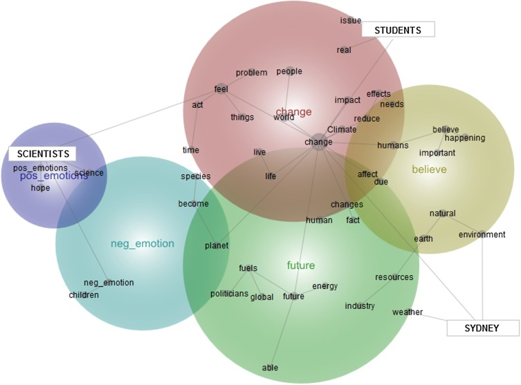

1. [Download: Download high-res image (465KB)](https://ars.els-cdn.com/content/image/1-s2.0-S095937801731004X-gr3_lrg.jpg)
2. [Download: Download full-size image](https://ars.els-cdn.com/content/image/1-s2.0-S095937801731004X-gr3.jpg)

Fig. 3. Leximancer automatic output showing the relationship between scientist, student and general responses to how they feel about climate change.

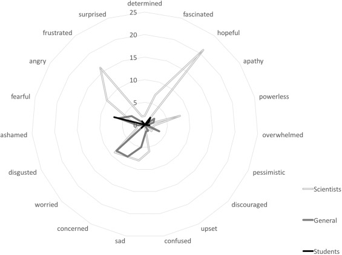

1. [Download: Download high-res image (182KB)](https://ars.els-cdn.com/content/image/1-s2.0-S095937801731004X-gr4_lrg.jpg)
2. [Download: Download full-size image](https://ars.els-cdn.com/content/image/1-s2.0-S095937801731004X-gr4.jpg)

Fig. 4. The frequency of emotion codes in qualitative responses from student, scientist and general samples. More frequent emotional content is depicted by greater deviation from the centre.

Table 3. Final themes for scientists, students and general population samples.

[output not shown]

Table 3. The qualitative responses from the general sample are in Supplementary Materials.

Using participants’ responses to the quantitative questions, we employed hierarchical clustering using Ward’s method, with distances computed using squared [Euclidean distance](https://www.sciencedirect.com/topics/psychology/euclidean-distance). The analysis allowed us to identify groups of participants who reported similar emotional responses to climate change, in so doing creating ‘profiles’ of emotions. With a visual inspection of the dendrogram, and using a range of internal validation criteria (e.g. Dunn index) computed through “clValid”, a package for R (Brock et al., 2008; see Supplementary materials for details), we determined that a both a 4-cluster and an 8-cluster solution would be acceptable structures, with the former being slightly better, likely due to sample size. The latter divided each of the four clusters into sub-groups. The 4-cluster solution was adopted, but we also looked at the subgroups created in the 8-cluster solution to explore the structure of the four cluster groups.

We began the analysis by looking at the 4-cluster solution, which revealed the following clusters: “Strong Negative Emotion” (N = 45), those who reported roughly the same negative emotions as scientists, particularly anger and fear, but with low hope; “Weak Negative Emotion” (N = 79), those who reported similar negative emotions, but at a low intensity; “No Emotion” (N = 49), those experiencing low intensity levels of both negative and positive emotion; and “Ambivalent” (N = 32), those experiencing both positive emotions and negative emotions. The relationship between profiles and measured emotions is shown in Fig. 5.

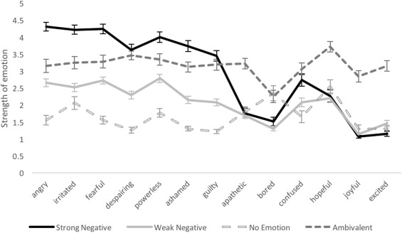

1. [Download: Download high-res image (178KB)](https://ars.els-cdn.com/content/image/1-s2.0-S095937801731004X-gr5_lrg.jpg)
2. [Download: Download full-size image](https://ars.els-cdn.com/content/image/1-s2.0-S095937801731004X-gr5.jpg)

Fig. 5. The four emotion profiles. The figure shows the intensity at which each of the measured emotions is experienced by participants in each profile.

To investigate how emotion profiles related to climate action, we compared the clusters on support for climate change policies, and support for budget increases to protect the environment. Fig. 6 shows standardised scores for both variables, for each emotion profile.

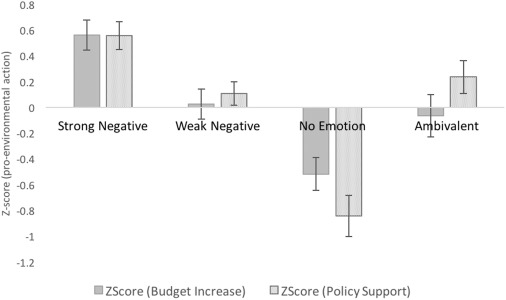

1. [Download: Download high-res image (149KB)](https://ars.els-cdn.com/content/image/1-s2.0-S095937801731004X-gr6_lrg.jpg)
2. [Download: Download full-size image](https://ars.els-cdn.com/content/image/1-s2.0-S095937801731004X-gr6.jpg)

Fig. 6. Support for budget increase and policy support by emotion profile. Standard error is shown.

The Strong Negative Emotion group showed high support for both policy support and budget increase, whereas the No Emotion group showed low support for both. As there were unequal cell sizes between cluster groups, a non-parametric [multivariate analysis](https://www.sciencedirect.com/topics/agricultural-and-biological-sciences/multivariate-analysis) was conducted to assess differences between clusters. A Kruskall-Wallis test showed significant differences between groups for both policy support, χ<sup>2</sup> (3) = 45.504, p < 0.001, and budget increases, χ<sup>2</sup> (3) = 40.277, p < 0.001.

Post-hoc comparisons using Mann-Whitney tests show that Strong Negative Emotion and Weak Negative Emotion differed for both policy support, p = 0.002, r<sup>2</sup> = 0.07, and budget increase, p = 0.003, r<sup>2</sup> = 0.07. Similarly, Weak Negative Emotion also differed significantly from the No Emotion group for both policy support, p < 0.001, r<sup>2</sup> = 0.11, and budget increase, p < 0.001, r<sup>2</sup> = 0.16. Finally, a comparison of Weak Negative Emotion and Ambivalent groups showed no significant difference between groups for either policy support, p = 0.658, or budget increase, p = 0.858. For a detailed analysis of emotion clusters with other climate change-related variables, see Supplementary Material.

We also analysed the objects of care mentioned by the participants, according to these four profiles. Not all participants mentioned any objects of care, as the question only asked about emotions – for those who did, the objects that they were concerned about emerged spontaneously. A list of 19 objects of care were mentioned by participants, ranging from “future generations” as the most common, to specific places such as the Great Barrier Reef.

Fig. 7 shows the frequency with which each object of care was mentioned, according to cluster group. The Strong Negative cluster generated the most mentions of objects of care (42), despite there being only 45 participants. The Weak Negative cluster (N = 79) generated 30 objects of care, and the Ambivalent cluster (N = 32) generated 13, while the No Emotion group (N = 49) generated only 4. Of the objects of care mentioned, “future generations” were the most common (27 times), followed by “animals” (12), and “the environment” (8).

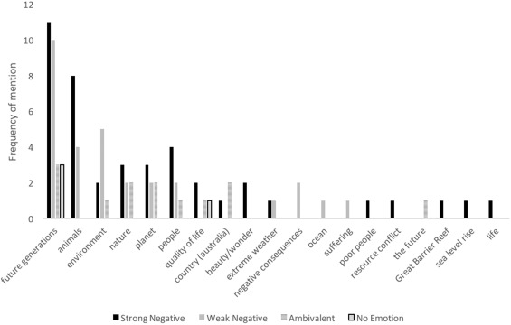

1. [Download: Download high-res image (156KB)](https://ars.els-cdn.com/content/image/1-s2.0-S095937801731004X-gr7_lrg.jpg)
2. [Download: Download full-size image](https://ars.els-cdn.com/content/image/1-s2.0-S095937801731004X-gr7.jpg)

Fig. 7. Qualitative mentions of “objects of care” by each cluster.

Although the 8-cluster solution was not as optimal as the 4-cluster solution, it still provided a decent fit to the data. This solution divided Strong Negative, Weak Negative and No Emotion clusters into smaller sub-groups. Although the cell sizes for some of these

groups are small, we examined these subgroups further (Table 4

Table 4. Clusters of emotion profiles.

| Part of cluster | Name | N | Highs | Lows | Intensity | Description |
| --- | --- | --- | --- | --- | --- | --- |
| Strong Negative | Self-blame | 19 | Shame, guilt, powerless, despair, fear, anger | Joy, boredom, excitement | High | Strong negative emotion with self-referential emotions |
| Strong Negative | Other-blame | 26 | Anger, fear, irritation | Joy, hope, excitement, boredom, apathy | High | Strong negative emotion *without* self-referential emotions |
| Weak Negative | Moderate Optimist | 12 | Hope, anger, excitement, fear | Despair, joy | Low | Medium negative emotions. Highest in hope and excitement |
| Weak Negative | Low self-blame | 37 | Anger, fear, powerlessness, shame | Boredom, joy | Low | Similar to “self-blame” but lower intensity |
| Weak Negative | Scared & Confused | 30 | Fear, powerlessness, confusion | Joy, boredom | Low | Weakly felt emotions, mostly in fear and powerlessness |
| No Emotion | Disengaged Optimist | 34 | Hope | Everything else | Low | Positive but apathetic |
| No Emotion | Fed Up | 15 | Boredom, irritation | Everything else | High | Bored and irritated with the issue |
| Ambivalent | Ambivalent | 32 | Hope, apathy, despair, excitement | Everything else medium | Medium | Medium scores in everything |

). The Strong Negative Emotion cluster was split into two groups that differed with respect to self-referential emotions relating to blame (shame and guilt), one group had high scores in self-blaming emotions such as shame and guilt, while the other had lower scores. The Weak Negative emotion cluster split into three groups: a low intensity self-blame group, a group that primarily reported fear and confusion, and a group that showed primarily hope. The No

Emotion group was divided into two as well: a group of participants with low emotion scores for everything except hope, and another with low scores for everything except boredom and irritation. The ambivalent group remained the same. The relationship between sub-groups and emotion is shown in Fig. 8, Fig. 9.

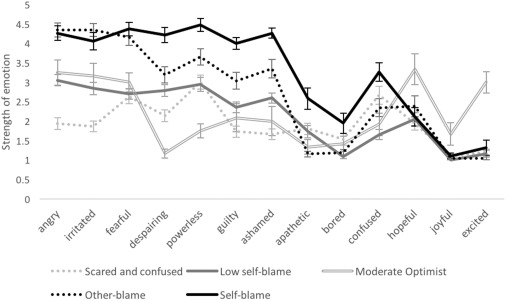

1. [Download: Download high-res image (195KB)](https://ars.els-cdn.com/content/image/1-s2.0-S095937801731004X-gr8_lrg.jpg)
2. [Download: Download full-size image](https://ars.els-cdn.com/content/image/1-s2.0-S095937801731004X-gr8.jpg)

Fig. 8. Sub-groups for Weak Negative (grey) and Strong Negative (black) clusters.

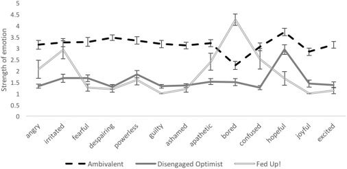

1. [Download: Download high-res image (140KB)](https://ars.els-cdn.com/content/image/1-s2.0-S095937801731004X-gr9_lrg.jpg)
2. [Download: Download full-size image](https://ars.els-cdn.com/content/image/1-s2.0-S095937801731004X-gr9.jpg)

Fig. 9. Sub-groups for No Emotion (grey) cluster and Ambivalent (black) cluster.

The relationship between sub-groups and climate action is shown in Fig. 10. The findings mirror that of the four clusters, but the analysis of sub-groups reveals important differences, particularly for the Weak Negative cluster. Notably, the “Scared and Confused” subgroup is less willing to support climate action than the other two sub-groups in the cluster. On the other hand, the “Low Self Blame” group appears to act similarly to the sub-groups within the Strong Negative Emotion cluster. We conducted further analyses to see if there were significant differences between groups.

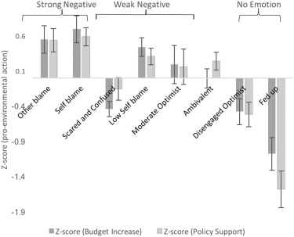

1. [Download: Download high-res image (147KB)](https://ars.els-cdn.com/content/image/1-s2.0-S095937801731004X-gr10_lrg.jpg)
2. [Download: Download full-size image](https://ars.els-cdn.com/content/image/1-s2.0-S095937801731004X-gr10.jpg)

Fig. 10. Support for budget increase and policy by sub-group. Standard error is shown.

First, a Kruskall-Wallis test was conducted to detect any differences between sub-groups, finding differences for both policy support, χ<sup>2</sup> (7) = 55.744, p < 0.001, and budget increases, χ<sup>2</sup> (7) = 58.804, p < 0.001.

Post-hoc comparisons using Mann-Whitney tests show that the Strong Negative Emotion subgroups (Other-blame and Self-blame) did not differ from each other, for either budget increase (p = 0.618) or policy support (p = 0.629). The Self-blame subgroup (Strong Negative) also did not differ from Low Self-blame (Weak Negative) for either budget increase (p = 0.351) or policy support (p = 0.294).

For the sub-groups in the Weak Negative Emotion cluster, the “Low Self-blame” group differed from the “Scared and Confused” group for both budget increase, p = 0.016, r<sup>2</sup> = 0.04, and policy support, p < 0.001, r<sup>2</sup> = 0.07.<sup>1</sup> The other sub-group within this cluster “Moderate Optimist” also differed from the “Scared and Confused” subgroup, for budget increase, p = 0.013, r<sup>2</sup> < 0.001, but not policy support (p = 0.328), likely due to the small cell size (N = 12).

The “Scared and Confused” subgroup did not differ significantly from the “Disengaged Optimist” group (No Emotion cluster) for budget increase, p = 0.299, or policy support, p = 0.513. Finally, the two No Emotion clusters did differ significantly from each other for policy support, p = 0.015, r = 0.04, but not budget increase, p = 0.108, again, likely due to the small sample size of the “Fed Up” group (N = 15).

### 3.3. Discussion

In Study 2 we aimed to compare findings from Study 1 with responses sampled from a general population, and to explore whether emotional responses to climate change had consequences for climate action.

The themes that arose from analysis of Study 2 were somewhere in between those of the student and climate scientist samples. The themes “Belief” and “Action” were reflected in student concerns, while the themes corresponding to “Emotion” and “Preserve Earth” were similar to scientist responses. We cannot be sure whether differences between student and general samples are due to real differences, or whether they are due to more strongly emphasising in Study 2 that respondents should describe their “emotional” responses to climate change. Despite this, the level of emotional content does not differ between general and student samples, and scientists clearly displayed a greater range and frequency of emotional response than both. Overall, scientists expressed more frustration, anger, and more hope than either of the other samples, unlikely to have been a product of differences in instructions.

The scientist and general samples both mentioned future generations and nature as objects of care, describing close relationships to both. However, while identity played a role in shaping scientists’ responses to climate change, it did not have the same prominence in the general sample. Instead of manifesting as a connector to climate change, identity may have played a part in distancing oneself from responsibility. In the “Action” theme, many focused on a national-level, Australian identity, and pinpointed national government as the responsible actor, and source of blame for inaction. This corresponds with findings that identity can be used to negotiate personal responsibility for action (Caillaud et al., 2015).

In the quantitative results, emotion profiles predicted significant differences in behavioural intentions toward climate change. One group, Strong Negative Emotion (high anger, shame, and fear) was significantly more likely to support climate change policies and greater budget allocation to the environment than other groups. This group showed greater support for policy and budget increases than the Weak Negative Emotion profile, which in turn showed greater support than the No Emotion profile. While the Strong Negative Emotion group differed from the reported emotions of scientists – namely, a lack of hope – the group still maintained greater support for climate action.

The additional analyses of the 8-subgroups also showed that within these groups, there are potentially important findings. Within the Strong Negative Emotion group, one group showed higher self-blaming emotions (guilt, shame), but there was no difference between their behavioural intentions. However, self-blaming emotions, even at moderate levels, may increase support for climate action more than other emotions. We saw this in the “Low Self-blame” subgroup, which, despite reporting lower intensity of negative emotions, did not differ from the Strong Negative Emotion subgroups on policy support and budget increase. On the other hand, those who reported being mostly fearful and confused reported as little support for climate action as those who felt virtually no emotions towards climate change – the least engaged group. While promising, the sub-groups were small, hence these results are preliminary, and need verification with larger samples.

These profiles suggest that responses to climate change may be differentiated by emotion, as they have been elsewhere (see e.g., Leiserowitz et al., 2009 and Hine et al., 2015), but we are not necessarily suggesting a segmentation approach. Emotional responses such as these appear to be fluid concepts, dependent upon perceptions of threat to valued objects. For those who feel strongly about climate change, being asked about their feelings also brought to mind the valued objects affected by climate change. In Supplementary Materials, we show that of all the clusters, the Strong Negative Emotion cluster spontaneously generated the largest range of objects of care, and with the greatest frequency. Importantly, when caring about climate change, the specific objects of care may differ for different people, but the emotional responses arising from perceived threat are similar, and predict support for climate action in similar ways. For this reason, we should be careful not to treat the emotional responses as the cause of the behaviour, as they are only a symptom. With greater consideration of the objects of care that can connect people to climate change, we can understand emotional and behavioural consequences more clearly.

The results showed that a general population sample discussed similar objects of care as scientists, and similar concerns about attributions of climate change as students. These responses were captured in clusters of distinct emotional responses to climate change, which predicted support for climate policies. The emotion profile that most closely resembled scientists’ qualitative reports predicted the greatest levels of support for climate policies.

## 4. General discussion

### 4.1. Overview of key findings and implications

Current research shows that emotions can play a motivating role in climate action, but the precise way in which emotions relate to this motivation—why people care about climate change—has received less attention. The proposed conceptualisation of “caring about climate change” argues that climate change may not be the focus, but rather, other “objects of care” motivate caring about climate change. Two hypotheses follow: that these objects trigger emotional responses to climate change, and that the emotional responses to climate change predict climate action. In two studies, we examined these two hypotheses in turn.

Climate scientists not only described more emotions, and more intense emotions, than both the student sample and the general population sample, these emotions were linked to particular “objects of care” (future generations, the planet) described by respondents as under threat from climate change. Closeness to these entities – future generations as children, and the planet as a friend or nurturing force – appears to be paired with the emotional closeness to climate change as an issue. This aligns with findings from the qualitative literature indicating that factors such as attachment to nature and anticipated harm to future generations form connections to the issue of climate change (Lefsrud and Meyer, 2012; Byg and Salick, 2009; Norgaard, 2006).

With a broader sample, we found profiles of emotional responses to climate change which explained differences in support for climate policies. Notably, the profile most resembling that of scientists was related to the greatest support for climate policies and environmental budget allocation, and mentioned the most “objects of care” as reasons for their emotional responses.

These findings substantiate our conceptualisation of “caring about climate change”. Objects of care that link people to climate change may be crucial to understanding why some people feel more strongly about the issue than others. These “objects of care” may bridge the psychological distance between the self and climate change, making the issue of climate change seem more personally relevant, evoking stronger emotions, and prompting action.

This is not to say that people who do not care about climate change also do not care about future generations, or the Earth. For example, conservative appeals for fiscal responsibility also cite the welfare of future generations. Instead, the connection between those objects of care, and the threat of climate change may be stronger, more apparent for some than others, which could be a result of many factors, including the idea that we have a “finite pool of worry” (Whitmarsh, 2011). For some, the threat to objects of care (future generations) may take a different route, through financial rather than environmental security. For others, a possibility is that having made the connections, the emotions one experiences are uncomfortable or overwhelming, leading to motivated distancing from the issue (Leviston et al., 2014b).

If climate change is perceived as a threat to something about which we care, then identifying core objects of care may help us understand climate change engagement. Indeed, public engagement programs are beginning to highlight climate change consequences, not just to the Earth and climate systems, but to human society, mental and physical health (Clayton et al., 2014), and these may be crucial. Some work is being done in this area. Based on research with focus groups (Climate Outreach, 2014), the Climate Coalition ran a campaign centered around the emotional and psychological closeness of climate change titled: “*For the love of… let’s do something about climate change”,* to bring climate change closer to individuals by highlighting that climate change will affect things that they care about (The Climate Coalition, 2016).

A related point is how respondents used identities to frame their own role in climate action. For scientists, climate change was entrenched in multiple self-identities, and these identities were linked to statements about their responsibility to act. It is also worth noting that feeling self-referential emotions such as shame and guilt towards the issue may indicate that the individual perceives a stronger role for themselves in climate action. At present, identities are largely absent from the discourse around climate change (Ballantyne et al., 2015), and this is reflected in general and student samples. There is an opportunity to expand climate change communication to connect climate change with different identities. The way in which identities were expressed by scientists suggests that it is possible to engage with climate change in many ways, even within the same individual, and making one identity salient may bring attention to different objects of care.

### 4.2. Limitations and future directions

Finally, despite clear differences between groups, there were also differences within them. Scientist responses were far from homogenous, and it is unlikely that all climate scientists feel the same way about climate change; the emotions and cognitions reported suggest that there may be additional types of emotional responses to climate change. Relatedly, scientists’ participation in the ITHYF project was in part self-selected, as they chose whether or not they would send in a response. It is possible that those who care more about climate change may have been more likely to participate. However, the intention behind the inclusion of this data was not to show a representative sample of climate scientists, but rather to present a specific group who cared about climate change. Nonetheless, it would also be valuable to look at other groups that may “care about climate change” strongly, such as activists, or people directly affected by climate change – even sceptics.

## 5. Conclusion

In two studies, this paper defined what it might mean to care about climate change. We provided insight into *why* people feel specific, or any, emotions about climate change, and linked these emotions to support for climate policy and budget allocation. This paper provided a detailed look at how scientists, students and a general population engage with and feel about climate change.

We demonstrated a connection between objects of care, the emotions they evoke, and actions to address climate change. The concept of “objects of care” encompasses valued objects, people and places in one’s life, as well as core identities. Herein lies the value of a Lewinian framework, which can integrate concepts from different theoretical branches of psychology, and explain their relationship to emotion and action.

To broaden engagement with climate change, future climate communication efforts may benefit from focusing messages on the things that people care about, and by appealing to the different self-conceptions and identities that orient people to climate change. Linking climate change and other objects (e.g., focusing on different objects of care or appealing to different identities) can promote broader connectivity of the issue. Such discourse would emphasise that climate change is not an isolated phenomenon, but one that is connected to many areas of life, and to the lives of other beings.

## Acknowledgement

We would like to thank Joe Duggan for allowing us to use the data from the “Is This How You Feel” Project.

## Appendix A. Supplementary data

The following is Supplementary data to this article:[Download: Download Word document (5MB)](https://ars.els-cdn.com/content/image/1-s2.0-S095937801731004X-mmc1.docx)

## References

1. Australian Bureau of Statistics, 2014

   ABS (Australian Bureau of Statistics), (2014). Population by Age and Sex, Regions of Australia, 2014. Cat. No. 3235.0. Canberra, Australia.

   Google Scholar
2. Albrecht et al., 2007

   G. Albrecht, *et al.*

   Solastalgia: the distress caused by environmental change

   Australas Psychiatry, 15 (1) (2007), pp. S95-S98

   [Crossref](https://doi.org/10.1080/10398560701701288)[View in Scopus](https://www.scopus.com/inward/record.url?eid=2-s2.0-36348980465&partnerID=10&rel=R3.0.0)[Google Scholar](https://scholar.google.com/scholar_lookup?title=Solastalgia%3A%20the%20distress%20caused%20by%20environmental%20change&publication_year=2007&author=G.%20Albrecht)

   1,104

   6

   581

   1
3. Ballantyne et al., 2015

   A. Ballantyne, V. Wibeck, T.S. Neset

   Images of climate change: a pilot stidy of young people's perceptions of ICT-based climate visualization

   Clim. Change, 134 (2015), pp. 73-85

   Google Scholar
4. Bamberg and Möser, 2007

   S. Bamberg, G. Möser

   Twenty years after Hines, Hungerford, and Tomera: a new meta-analysis of psycho-social determinants of pro-environmental behaviour

   J. Environ. Psychol., 27 (1) (2007), pp. 14-25

   [View PDF](https://www.sciencedirect.com/science/article/pii/S0272494406000909/pdfft?md5=a72249f12203748b9c050be7f6f81c3a&pid=1-s2.0-S0272494406000909-main.pdf)[View article](https://www.sciencedirect.com/science/article/pii/S0272494406000909)[View in Scopus](https://www.scopus.com/inward/record.url?eid=2-s2.0-33947131686&partnerID=10&rel=R3.0.0)Google Scholar
5. Bissing-Olson et al., 2016

   M.J. Bissing-Olson, K.S. Fielding, A. Iyer

   Experiences of pride, not guilt, predict pro-environmental behavior when pro-environmental descriptive norms are more positive

   J. Environ. Psychol., 45 (2016), pp. 145-153

   https://doi.org/10.1016/j.jenvp.2016.01.001

   [View PDF](https://www.sciencedirect.com/science/article/pii/S0272494416300019/pdfft?md5=e110d82db98117c03ab8c7877a931da3&pid=1-s2.0-S0272494416300019-main.pdf)[View article](https://www.sciencedirect.com/science/article/pii/S0272494416300019)[View in Scopus](https://www.scopus.com/inward/record.url?eid=2-s2.0-84953857998&partnerID=10&rel=R3.0.0)Google Scholar

   295

   9

   210

   2
6. Böhm, 2003

   G. Böhm

   Emotional reactions to environmental risks: consequentialist versus ethical evaluation

   J. Environ. Psychol., 23 (2003), pp. 199-212

   [View PDF](https://www.sciencedirect.com/science/article/pii/S0272494402001147/pdfft?md5=741a4b6808edac8bf44d2dbed5a314a3&pid=1-s2.0-S0272494402001147-main.pdf)[View article](https://www.sciencedirect.com/science/article/pii/S0272494402001147)[View in Scopus](https://www.scopus.com/inward/record.url?eid=2-s2.0-0038172360&partnerID=10&rel=R3.0.0)[Google Scholar](https://scholar.google.com/scholar_lookup?title=Emotional%20reactions%20to%20environmental%20risks%3A%20consequentialist%20versus%20ethical%20evaluation&publication_year=2003&author=G.%20B%C3%B6hm)
7. Böhm and Pfister, 2000

   G. Böhm, H.-R. Pfister

   Action tendencies and characteristics of environmental risks

   Acta Psychol., 104 (2000), pp. 317-337

   [View PDF](https://www.sciencedirect.com/science/article/pii/S0001691800000354/pdfft?md5=b68daeec6244b272c9df220505b1c4bb&pid=1-s2.0-S0001691800000354-main.pdf)[View article](https://www.sciencedirect.com/science/article/pii/S0001691800000354)[View in Scopus](https://www.scopus.com/inward/record.url?eid=2-s2.0-0034202826&partnerID=10&rel=R3.0.0)[Google Scholar](https://scholar.google.com/scholar_lookup?title=Action%20tendencies%20and%20characteristics%20of%20environmental%20risks&publication_year=2000&author=G.%20B%C3%B6hm&author=H.-R.%20Pfister)
8. Böhm and Pfister, 2017

   G. Böhm, H.-R. Pfister

   The perceiver’s social role and a risk’s causal structure as determinants of environmental risk evaluation

   J. Risk Res. (2017)

   https://doi.org/10.1080/13669877.2015.1118148

   Google Scholar

   37

   0

   32

   1
9. Brock et al., 2008

   G. Brock, V. Pihur, S. Datta, S. Datta

   clValid, an R package for cluster validation

   J. Stat. Software, 25 (4) (2008), pp. 1-22, 10.18637/jss.v025.i04

   [View in Scopus](https://www.scopus.com/inward/record.url?eid=2-s2.0-46749142532&partnerID=10&rel=R3.0.0)[Google Scholar](https://scholar.google.com/scholar_lookup?title=clValid%2C%20an%20R%20package%20for%20cluster%20validation&publication_year=2008&author=G.%20Brock&author=V.%20Pihur&author=S.%20Datta&author=S.%20Datta)

   815

   2

   588

   0
10. Brügger, 2013

    A. Brügger

    Fear Appeals and Localising Climate Change: Neither is a Panacea to Motivate Action on Climate Change

    University of Exeter (2013)

    Thesis

    Google Scholar
11. Brügger et al., 2015

    A. Brügger, *et al.*

    Psychological responses to the proximity of climate change

    Nat. Clim. Change, 5 (12) (2015), pp. 1031-1037

    http://ht.ly/35qr98

    [Crossref](https://doi.org/10.1038/nclimate2760)[View in Scopus](https://www.scopus.com/inward/record.url?eid=2-s2.0-84948138182&partnerID=10&rel=R3.0.0)[Google Scholar](https://scholar.google.com/scholar_lookup?title=Psychological%20responses%20to%20the%20proximity%20of%20climate%20change&publication_year=2015&author=A.%20Br%C3%BCgger)

    338

    10

    262

    0
12. Brügger et al., 2011

    A. Brügger, F.G. Kaiser, N. Roczen

    One for all?: connectedness to nature, inclusion of nature, environmental identity, and implicit association with nature

    Eur. Psychol., 16 (4) (2011), pp. 324-333

    [Crossref](https://doi.org/10.1027/1016-9040/a000032)[View in Scopus](https://www.scopus.com/inward/record.url?eid=2-s2.0-83455172597&partnerID=10&rel=R3.0.0)Google Scholar

    276

    9

    152

    0
13. Byg and Salick, 2009

    A. Byg, J. Salick

    Local perspectives on a global phenomenon-climate change in Eastern Tibetan villages

    Global Environ. Change, 19 (2) (2009), pp. 156-166

    [View PDF](https://www.sciencedirect.com/science/article/pii/S0959378009000193/pdfft?md5=f45335146d1668b57abe67d2845ff33f&pid=1-s2.0-S0959378009000193-main.pdf)[View article](https://www.sciencedirect.com/science/article/pii/S0959378009000193)[View in Scopus](https://www.scopus.com/inward/record.url?eid=2-s2.0-67349140653&partnerID=10&rel=R3.0.0)Google Scholar
14. Caillaud et al., 2015

    S. Caillaud, *et al.*

    How groups cope with collective responsibility for ecological problems: symbolic coping and collective emotions

    Br. J. Soc. Psychol. (2015), pp. 297-317

    Google Scholar
15. Chapman et al., 2017

    D. Chapman, B. Lickel, E. Markowitz

    Reassessing emotion in climate change communication

    Nat. Clim. Change, 7 (2017), pp. 850-852

    https://doi.org/10.1038/s41558-017-0021-9

    [Crossref](https://doi.org/10.1038/s41558-017-0021-9)[View in Scopus](https://www.scopus.com/inward/record.url?eid=2-s2.0-85036633378&partnerID=10&rel=R3.0.0)[Google Scholar](https://scholar.google.com/scholar_lookup?title=Reassessing%20emotion%20in%20climate%20change%20communication&publication_year=2017&author=D.%20Chapman&author=B.%20Lickel&author=E.%20Markowitz)

    287

    9

    186

    0
16. Charmaz, 2014

    K. Charmaz

    Constructing Grounded Theory

    Sage Publications, London, UK (2014)

    [Google Scholar](https://scholar.google.com/scholar_lookup?title=Constructing%20Grounded%20Theory&publication_year=2014&author=K.%20Charmaz)
17. Cheung et al., 2014

    W.Y. Cheung, M.A. Luke, G.R. Maio

    On attitudes towards humanity and climate change: the effects of humanity esteem and self-transcendence values on environmental concerns

    Eur. J. Soc. Psychol., 44 (5) (2014), pp. 496-506

    [Crossref](https://doi.org/10.1002/ejsp.2037)[View in Scopus](https://www.scopus.com/inward/record.url?eid=2-s2.0-84904973026&partnerID=10&rel=R3.0.0)Google Scholar

    36

    3

    37

    1
18. Clayton et al., 2014

    S. Clayton, C. Manning, C. Hodge

    Beyond Storms & Droughts: The Psychological Impacts of Climate Change

    Washington, DC

    (2014)

    Google Scholar
19. Climate Council, 2016

    Climate Council

    Scared Scientists

    (2016)

    (Accessed November 28, 2016)

    http://cargocollective.com/scared_scientists

    [Google Scholar](https://scholar.google.com/scholar_lookup?title=Scared%20Scientists&publication_year=2016&author=Climate%20Council)
20. Climate Outreach, 2014

    Climate Outreach

    How Narrative Workshops Informed a National Climate Change Campaign: Summary of Report for The Climate Coalition

    Oxford, UK

    (2014)

    Google Scholar
21. Davis et al., 2011

    J.I. Davis, J.J. Gross, K.N. Ochsner

    Psychological distance and emotional experience: what you see is what you get

    Emotion, 11 (2) (2011), pp. 438-444

    (Washington, D.C.)

    [Crossref](https://doi.org/10.1037/a0021783)[View in Scopus](https://www.scopus.com/inward/record.url?eid=2-s2.0-79955156808&partnerID=10&rel=R3.0.0)Google Scholar

[figure not shown]

    118

    4

    76

    1
22. Devine-Wright, 2013

    P. Devine-Wright

    Think global, act local? The relevance of place attachments and place identities in a climate changed world

    Global Environ. Change, 23 (1) (2013), pp. 61-69, 10.1016/j.gloenvcha.2012.08.003

    [View PDF](https://www.sciencedirect.com/science/article/pii/S0959378012001100/pdfft?md5=75e43eca3e103fe35e1901d78f6d1027&pid=1-s2.0-S0959378012001100-main.pdf)[View article](https://www.sciencedirect.com/science/article/pii/S0959378012001100)[View in Scopus](https://www.scopus.com/inward/record.url?eid=2-s2.0-84872610112&partnerID=10&rel=R3.0.0)Google Scholar

    387

    2

    197

    0
23. Dickinson, 2009

    J.L. Dickinson

    The people paradox: self-esteem striving, immortality ideologies, and human response to climate change

    Ecol. Soc., 14 (1) (2009)

    Google Scholar
24. Duggan, 2015

    J. Duggan

    Is This How You Feel?

    (2015)

    http://www.isthishowyoufeel.com

    [Google Scholar](https://scholar.google.com/scholar_lookup?title=Is%20This%20How%20You%20Feel&publication_year=2015&author=J.%20Duggan)
25. Farbotko and McGregor, 2010

    C. Farbotko, H.V. McGregor

    Copenhagen, climate science and the emotional geographies of climate change

    Aust. Geogr., 41 (2) (2010), pp. 159-166

    [https://www.scopus.com/inward/record.uri?eid=2-s2.0-77953495953&partnerID=40&md5=6cd1116aba03f6c8c509174ba1578c39](https://www.scopus.com/inward/record.uri?eid=2-s2.0-77953495953%26partnerID=40%26md5=6cd1116aba03f6c8c509174ba1578c39)

    [Crossref](https://doi.org/10.1080/00049181003742286)[View in Scopus](https://www.scopus.com/inward/record.url?eid=2-s2.0-77953495953&partnerID=10&rel=R3.0.0)Google Scholar

    64

    0

    33

    0
26. Ferguson and Branscombe, 2010

    M.A. Ferguson, N.R. Branscombe

    Collective guilt mediates the effect of beliefs about global warming on willingness to engage in mitigation behavior

    J. Environ. Psychol., 30 (2) (2010), pp. 135-142, 10.1016/j.jenvp.2009.11.010

    [View PDF](https://www.sciencedirect.com/science/article/pii/S0272494409001030/pdfft?md5=a4eff0992d90ff70da4eda0a9b142bc6&pid=1-s2.0-S0272494409001030-main.pdf)[View article](https://www.sciencedirect.com/science/article/pii/S0272494409001030)[View in Scopus](https://www.scopus.com/inward/record.url?eid=2-s2.0-77952887607&partnerID=10&rel=R3.0.0)Google Scholar

    305

    15

    185

    0
27. Fernando et al., 2014

    J.W. Fernando, Y. Kashima, S.M. Laham

    Multiple emotions: a person-centered approach to the relationship between intergroup emotion and action orientation

    Emotion, 14 (4) (2014), pp. 722-732, 10.1037/a0036103

    [View in Scopus](https://www.scopus.com/inward/record.url?eid=2-s2.0-84905115367&partnerID=10&rel=R3.0.0)Google Scholar

    58

    4

    62

    0
28. Fischer et al., 2012

    A. Fischer, *et al.*

    Climate change? No, wise Resource use is the issue: social representations of energy, climate change and the future

    Environ. Policy Gov., 22 (3) (2012), pp. 161-176

    [Crossref](https://doi.org/10.1002/eet.1585)[View in Scopus](https://www.scopus.com/inward/record.url?eid=2-s2.0-84861918337&partnerID=10&rel=R3.0.0)Google Scholar

    61

    2

    41

    0
29. Gifford, 2011

    R. Gifford

    The dragons of inaction: psychological barriers that limit climate change mitigation and adaptation

    Am. Psychol., 66 (4) (2011), pp. 290-302

    [https://www.scopus.com/record/display.uri?eid=2-s2.0-79955964174&origin=inward&txGid=5e34b801a06c876bd94d46cc72139fe1](https://www.scopus.com/record/display.uri?eid=2-s2.0-79955964174%26origin=inward%26txGid=5e34b801a06c876bd94d46cc72139fe1)

    [Crossref](https://doi.org/10.1037/a0023566)[View in Scopus](https://www.scopus.com/inward/record.url?eid=2-s2.0-79955964174&partnerID=10&rel=R3.0.0)Google Scholar

    2,008

    21

    1,308

    1
30. Gifford and Nilsson, 2014

    R. Gifford, A. Nilsson

    Personal and social factors that influence pro-environmental concern and behaviour: a review

    Int. J. Psychol. J. Int. de Psychologie, 49 (3) (2014), pp. 141-157

    https://www.ncbi.nlm.nih.gov/pubmed/24821503

    [View in Scopus](https://www.scopus.com/inward/record.url?eid=2-s2.0-85006340074&partnerID=10&rel=R3.0.0)Google Scholar
31. Hine et al., 2015

    D.W. Hine, W.J. Phillips, R. Cooksey, J.P. Reser, P. Nunn, A.D.G. Marks, N.M. Loi, S.E. Watt

    Preaching to different choirs: how to motivate dismissive, uncommitted, and alarmed audiences to adapt to climate change?

    Global Environ. Change, 36 (2015), pp. 1-11

    [Crossref](https://doi.org/10.5130/ijrlp.i1.2015.4365)Google Scholar

    1

    0

    1

    0
32. Huang, 2016

    R. Huang

    RQDA: R-based Qualitative Data Analysis

    (2016)

    http://rqda.r-forge.r-project.org/

    [Google Scholar](https://scholar.google.com/scholar_lookup?title=RQDA%3A%20R-based%20Qualitative%20Data%20Analysis&publication_year=2016&author=R.%20Huang)
33. Hackenbracht and Gasper, 2013

    J. Hackenbracht, K. Gasper

    Feeling more and feeling close: affect intensity influences judgments of interpersonal closeness

    Soc. Cognit., 31 (1) (2013), pp. 94-105, 10.1521/soco.2013.31.1.94

    [View in Scopus](https://www.scopus.com/inward/record.url?eid=2-s2.0-84879754705&partnerID=10&rel=R3.0.0)Google Scholar

    8

    0

    4

    0
34. Harth et al., 2013

    N.S. Harth, C.W. Leach, T. Kessler

    Guilt, anger, and pride about in-group environmental behaviour: different emotions predict distinct intentions

    J. Environ. Psychol., 34 (2013), pp. 18-26, 10.1016/j.jenvp.2012.12.005

    [View PDF](https://www.sciencedirect.com/science/article/pii/S0272494412000849/pdfft?md5=2a4db76cd5525b47c403d7aa4569b00f&pid=1-s2.0-S0272494412000849-main.pdf)[View article](https://www.sciencedirect.com/science/article/pii/S0272494412000849)[View in Scopus](https://www.scopus.com/inward/record.url?eid=2-s2.0-84872563362&partnerID=10&rel=R3.0.0)Google Scholar

    320

    16

    242

    2
35. Hornsey and Fielding, 2016

    M.J. Hornsey, K.S. Fielding

    A cautionary note about messages of hope: focusing on progress in reducing carbon emissions weakens mitigation motivation

    Global Environ. Change, 39 (2016), pp. 26-34, 10.1016/j.gloenvcha.2016.04.003

    [View PDF](https://www.sciencedirect.com/science/article/pii/S0959378016300450/pdfft?md5=fb58df0efe94203be814600bf4a93821&pid=1-s2.0-S0959378016300450-main.pdf)[View article](https://www.sciencedirect.com/science/article/pii/S0959378016300450)[View in Scopus](https://www.scopus.com/inward/record.url?eid=2-s2.0-84964434849&partnerID=10&rel=R3.0.0)Google Scholar

    195

    9

    114

    3
36. Howe et al., 2015

    P.D. Howe, *et al.*

    Geographic variation in opinions on climate change at state and local scales in the USA

    Nature Climate Change (2015)

    [Google Scholar](https://scholar.google.com/scholar_lookup?title=Geographic%20variation%20in%20opinions%20on%20climate%20change%20at%20state%20and%20local%20scales%20in%20the%20USA&publication_year=2015&author=P.D.%20Howe)
37. Keller et al., 2012

    C. Keller, A. Bostrom, M. Kuttschreuter, L. Savadori, A. Spence, M. White

    Bringing appraisal theory to environmental risk perception: a review of conceptual approaches of the past 40 years and suggestions for future research

    J. Risk Res., 15 (2012), pp. 237-256

    [Crossref](https://doi.org/10.1080/13669877.2011.634523)[View in Scopus](https://www.scopus.com/inward/record.url?eid=2-s2.0-84856938388&partnerID=10&rel=R3.0.0)Google Scholar

    86

    4

    52

    0
38. Keltner and Lerner, 2010

    D. Keltner, J.S. Lerner

    Emotion

    S. Fiske, D.T. Gilbert, G. Lindzey (Eds.), Handbook of Social Psychology, John Wiley & Sons, New Jersey (2010)

    [Google Scholar](https://scholar.google.com/scholar_lookup?title=Emotion&publication_year=2010&author=D.%20Keltner&author=J.S.%20Lerner)
39. Kiefer and Velay, 2016

    M. Kiefer, J.L. Velay

    Writing in the digital age

    Trends in Neurosci. Educ., 5 (3) (2016), pp. 77-81

    [View PDF](https://www.sciencedirect.com/science/article/pii/S2211949316300205/pdfft?md5=c5be67ae9fc7d765f58be325dbee9a3b&pid=1-s2.0-S2211949316300205-main.pdf)[View article](https://www.sciencedirect.com/science/article/pii/S2211949316300205)[View in Scopus](https://www.scopus.com/inward/record.url?eid=2-s2.0-84991687588&partnerID=10&rel=R3.0.0)[Google Scholar](https://scholar.google.com/scholar_lookup?title=Writing%20in%20the%20digital%20age&publication_year=2016&author=M.%20Kiefer&author=J.L.%20Velay)
40. Lefsrud and Meyer, 2012

    L.M. Lefsrud, R.E. Meyer

    Science or Science Fiction? Professionals’ Discursive Construction of Climate Change

    (2012)

    http://oss.sagepub.com/content/33/11/1477.full

    Google Scholar
41. Leiserowitz, 2005

    A. Leiserowitz

    American risk perceptions: is climate change dangerous?

    Risk Anal., 25 (6) (2005), pp. 1433-1442

    [Crossref](https://doi.org/10.1111/j.1540-6261.2005.00690.x)[View in Scopus](https://www.scopus.com/inward/record.url?eid=2-s2.0-31944450145&partnerID=10&rel=R3.0.0)[Google Scholar](https://scholar.google.com/scholar_lookup?title=American%20risk%20perceptions%3A%20is%20climate%20change%20dangerous&publication_year=2005&author=A.%20Leiserowitz)

    803

    32

    527

    3
42. Leiserowitz, 2006

    A. Leiserowitz

    Climate change risk perception and policy preferences: the role of affect, imagery, and values

    Clim. Change, 77 (1–2) (2006), pp. 45-72

    [Crossref](https://doi.org/10.1007/s10584-006-9059-9)[View in Scopus](https://www.scopus.com/inward/record.url?eid=2-s2.0-33747710116&partnerID=10&rel=R3.0.0)Google Scholar

    1,970

    84

    1,393

    10
43. Leiserowitz et al., 2009

    A.A. Leiserowitz, E. Maibach, C. Roser-Renouf

    Global Warming’s “Six Americas,”

    Yale (2009)

    [Google Scholar](https://scholar.google.com/scholar_lookup?title=Global%20Warmings%20Six%20Americas%2C&publication_year=2009&author=A.A.%20Leiserowitz&author=E.%20Maibach&author=C.%20Roser-Renouf)
44. Leviston et al., 2014a

    Z. Leviston, *et al.*

    Fourth Annual Survey of Australian Attitudes to Climate Change: Interim Report

    CSIRO, Perth, Australia (2014)

    (Accessed May 28, 2014)

    [http://www.csiro.au/∼/media/CSIROau/Outcomes/Climate/Adapting/Climateattitudes/2013FourthsurveyofAustralianattitudestoclimatechange.pdf](http://www.csiro.au/~/media/CSIROau/Outcomes/Climate/Adapting/Climateattitudes/2013FourthsurveyofAustralianattitudestoclimatechange.pdf)

    [Google Scholar](https://scholar.google.com/scholar_lookup?title=Fourth%20Annual%20Survey%20of%20Australian%20Attitudes%20to%20Climate%20Change%3A%20Interim%20Report&publication_year=2014&author=Z.%20Leviston)
45. Leviston et al., 2014b

    Z. Leviston, J. Price, B. Bishop

    Imagining climate change: the role of implicit associations and affective psychological distancing in climate change responses

    Eur. J. Soc. Psychol., 44 (5) (2014), pp. 441-454, 10.1002/ejsp.2050

    [View in Scopus](https://www.scopus.com/inward/record.url?eid=2-s2.0-84904902068&partnerID=10&rel=R3.0.0)Google Scholar

    126

    1

    105

    2
46. Leviston and Walker, 2012

    Z. Leviston, I. Walker

    Beliefs and denials about climate change: an Australian perspective

    Ecopsychology, 4 (4) (2012), pp. 277-285, 10.1089/eco.2012.0051

    [View in Scopus](https://www.scopus.com/inward/record.url?eid=2-s2.0-84880457799&partnerID=10&rel=R3.0.0)[Google Scholar](https://scholar.google.com/scholar_lookup?title=Beliefs%20and%20denials%20about%20climate%20change%3A%20an%20Australian%20perspective&publication_year=2012&author=Z.%20Leviston&author=I.%20Walker)

    98

    6

    84

    1
47. Lewin, 1951

    K. Lewin

    D. Cartwright (Ed.), Field Theory in Social Science: Selected Theoretical Papers (1st ed.), Harper, New York (1951)

    [Google Scholar](https://scholar.google.com/scholar_lookup?title=Field%20Theory%20in%20Social%20Science%3A%20Selected%20Theoretical%20Papers&publication_year=1951&author=K.%20Lewin)
48. Lewin, 1936

    K. Lewin

    Principles of Topological Psychology

    McGraw-Hill Book Company, USA (1936)

    [Google Scholar](https://scholar.google.com/scholar_lookup?title=Principles%20of%20Topological%20Psychology&publication_year=1936&author=K.%20Lewin)
49. Lombardi and Sinatra, 2013

    D. Lombardi, G.M. Sinatra

    Emotions about teaching about human-induced climate change

    Int. J. Sci. Educ., 35 (1) (2013), pp. 167-191

    [Crossref](https://doi.org/10.1080/09500693.2012.738372)[View in Scopus](https://www.scopus.com/inward/record.url?eid=2-s2.0-85027939693&partnerID=10&rel=R3.0.0)[Google Scholar](https://scholar.google.com/scholar_lookup?title=Emotions%20about%20teaching%20about%20human-induced%20climate%20change&publication_year=2013&author=D.%20Lombardi&author=G.M.%20Sinatra)

    145

    4

    77

    1
50. Lu and Schuldt, 2016

    H. Lu, J.P. Schuldt

    Compassion for climate change victims and support for mitigation policy

    J. Environ. Psychol., 45 (2016), pp. 192-200

    https://doi.org/10.1016/j.jenvp.2016.01.007

    [View PDF](https://www.sciencedirect.com/science/article/pii/S027249441630007X/pdfft?md5=6e121839b6821e8cb735f4fa17f39f55&pid=1-s2.0-S027249441630007X-main.pdf)[View article](https://www.sciencedirect.com/science/article/pii/S027249441630007X)[View in Scopus](https://www.scopus.com/inward/record.url?eid=2-s2.0-84955257065&partnerID=10&rel=R3.0.0)[Google Scholar](https://scholar.google.com/scholar_lookup?title=Compassion%20for%20climate%20change%20victims%20and%20support%20for%20mitigation%20policy&publication_year=2016&author=H.%20Lu&author=J.P.%20Schuldt)

    88

    2

    53

    0
51. Lu and Schuldt, 2015

    H. Lu, J.P. Schuldt

    Exploring the role of incidental emotions in support for climate change policy

    Clim. Change, 131 (4) (2015), pp. 719-726

    [Crossref](https://doi.org/10.1007/s10584-015-1443-x)[View in Scopus](https://www.scopus.com/inward/record.url?eid=2-s2.0-84937972232&partnerID=10&rel=R3.0.0)[Google Scholar](https://scholar.google.com/scholar_lookup?title=Exploring%20the%20role%20of%20incidental%20emotions%20in%20support%20for%20climate%20change%20policy&publication_year=2015&author=H.%20Lu&author=J.P.%20Schuldt)

    83

    10

    52

    2
52. Mallett et al., 2013

    R.K. Mallett, K.J. Melchiori, T. Strickroth

    Self-confrontation via a carbon footprint calculator increases guilt and support for a proenvironmental group

    Ecopsychology, 5 (1) (2013), pp. 9-16

    http://online.liebertpub.com/doi/abs/10.1089/eco.2012.0067

    [Crossref](https://doi.org/10.1089/eco.2012.0067)[View in Scopus](https://www.scopus.com/inward/record.url?eid=2-s2.0-84882318769&partnerID=10&rel=R3.0.0)Google Scholar

    79

    2

    53

    2
53. Mcdonald et al., 2015

    R.I. Mcdonald, H.Y. Chai, B.R. Newell

    Personal experience and the “psychological distance” of climate change: an integrative review

    J. Environ. Psychol., 44 (2015), pp. 109-118

    https://doi.org/10.1016/j.jenvp.2015.10.003

    [View PDF](https://www.sciencedirect.com/science/article/pii/S0272494415300396/pdfft?md5=5512e3e522151bf699d706b0fe64363d&pid=1-s2.0-S0272494415300396-main.pdf)[View article](https://www.sciencedirect.com/science/article/pii/S0272494415300396)[View in Scopus](https://www.scopus.com/inward/record.url?eid=2-s2.0-84945916053&partnerID=10&rel=R3.0.0)Google Scholar

    591

    18

    384

    2
54. Mcdonald et al., 2013

    R.I. Mcdonald, B.R. Newell, M. Brewer

    Distancing climate change on four dimensions: implications for support for climate change action

    Sydney, Australia: Centre for Excellence in Climate System Science/School of Psychology, University of New South Wales, Psychology of Climate Change Symposium (2013)

    Google Scholar
55. Moloney and Walker, 2002

    G. Moloney, I. Walker

    Talking about transplants: social representations and the dialectical, dilemmatic nature of organ donation and transplantation

    Br. J. Soc. Psychol., 41 (2002), pp. 299-320

    http://www.ncbi.nlm.nih.gov/pubmed/12133230%5Cnhttp://onlinelibrary.wiley.com/doi/10.1348/014466602760060264/full

    [View in Scopus](https://www.scopus.com/inward/record.url?eid=2-s2.0-0036593926&partnerID=10&rel=R3.0.0)Google Scholar

    119

    8

    129

    0
56. Myers et al., 2012

    T.A. Myers, *et al.*

    A public health frame arouses hopeful emotions about climate change: a letter

    Clim. Change, 113 (3–4) (2012), pp. 1105-1112

    [Crossref](https://doi.org/10.1007/s10584-012-0513-6)[View in Scopus](https://www.scopus.com/inward/record.url?eid=2-s2.0-84864280890&partnerID=10&rel=R3.0.0)[Google Scholar](https://scholar.google.com/scholar_lookup?title=A%20public%20health%20frame%20arouses%20hopeful%20emotions%20about%20climate%20change%3A%20a%20letter&publication_year=2012&author=T.A.%20Myers)

    600

    12

    411

    5
57. Norgaard, 2006

    K.M. Norgaard

    “People want to protect themselves a little bit”: emotions, denial and social movement nonparticipation

    Sociol. Inq., 76 (3) (2006), pp. 372-396

    [View in Scopus](https://www.scopus.com/inward/record.url?eid=2-s2.0-33745469059&partnerID=10&rel=R3.0.0)Google Scholar
58. O’Neill and Nicholson-Cole, 2009

    S. O’Neill, S. Nicholson-Cole

    “Fear won’t do it”: promoting positive engagement with climate change through visual and iconic representations

    Sci. Commun., 30 (3) (2009), pp. 355-379

    [Crossref](https://doi.org/10.1177/1075547008329201)[View in Scopus](https://www.scopus.com/inward/record.url?eid=2-s2.0-60049096140&partnerID=10&rel=R3.0.0)Google Scholar

    1,193

    29

    407

    6
59. Ojala, 2012a

    M. Ojala

    Regulating worry, promoting hope: how do children, adolescents, and young adults cope with climate change?

    Int. J. Environ. Sci. Educ., 7 (4) (2012), pp. 537-561

    [https://www.scopus.com/inward/record.uri?eid=2-s2.0-84872896287&partnerID=40&md5=0fb1aa2eac8039bcaaf5d602b69e945a](https://www.scopus.com/inward/record.uri?eid=2-s2.0-84872896287%26partnerID=40%26md5=0fb1aa2eac8039bcaaf5d602b69e945a)

    [View in Scopus](https://www.scopus.com/inward/record.url?eid=2-s2.0-84872896287&partnerID=10&rel=R3.0.0)Google Scholar
60. Ojala, 2012b

    M. Ojala

    Hope and climate change: the importance of hope for environmental engagement among young people

    Environ. Educ. Res., 18 (5) (2012), pp. 625-642

    [Crossref](https://doi.org/10.1080/13504622.2011.637157)[View in Scopus](https://www.scopus.com/inward/record.url?eid=2-s2.0-84867284043&partnerID=10&rel=R3.0.0)Google Scholar

    773

    33

    489

    2
61. Pfister and Böhm, 2008

    H.-R. Pfister, G. Böhm

    The multiplicity of emotions: A framework of emotional functions in decision making

    Judgm. Decis. Making, 3 (2008), pp. 5-17

    [Crossref](https://doi.org/10.1017/s1930297500000127)[View in Scopus](https://www.scopus.com/inward/record.url?eid=2-s2.0-57349121802&partnerID=10&rel=R3.0.0)Google Scholar

    298

    2

    37

    0
62. Rees et al., 2015

    J.H. Rees, S. Klug, S. Bamberg

    Guilty conscience: motivating pro-environmental behavior by inducing negative moral emotions

    Clim. Change, 130 (3) (2015), pp. 439-452

    [Crossref](https://doi.org/10.1007/s10584-014-1278-x)[View in Scopus](https://www.scopus.com/inward/record.url?eid=2-s2.0-84930046997&partnerID=10&rel=R3.0.0)Google Scholar

    266

    9

    189

    2
63. Roeser, 2012

    S. Roeser

    Risk communication, public engagement, and climate change: a role for emotions

    Risk Anal., 32 (6) (2012), pp. 1033-1040

    [Crossref](https://doi.org/10.1111/j.1539-6924.2012.01812.x)[View in Scopus](https://www.scopus.com/inward/record.url?eid=2-s2.0-84862592625&partnerID=10&rel=R3.0.0)[Google Scholar](https://scholar.google.com/scholar_lookup?title=Risk%20communication%2C%20public%20engagement%2C%20and%20climate%20change%3A%20a%20role%20for%20emotions&publication_year=2012&author=S.%20Roeser)

    271

    8

    175

    1
64. Scannell and Gifford, 2011

    L. Scannell, R. Gifford

    Personally relevant climate change: the role of place attachment and local versus global message framing in engagement

    Environ. Behav., 45 (1) (2011), pp. 60-85, 10.1177/0013916511421196

    (Accessed May 28, 2014)

    Google Scholar

    617

    10

    170

    3
65. Siemer et al., 2007

    M. Siemer, I. Mauss, J.J. Gross

    Same situation–different emotions: how appraisals shape our emotions

    Emotion, 7 (3) (2007), pp. 592-600

    [Crossref](https://doi.org/10.1037/1528-3542.7.3.592)[View in Scopus](https://www.scopus.com/inward/record.url?eid=2-s2.0-34548817035&partnerID=10&rel=R3.0.0)Google Scholar

    337

    9

    246

    0
66. Slovic et al., 2004

    P. Slovic, *et al.*

    Risk as analysis and risk as feelings

    Risk Anal., 24 (2) (2004), pp. 311-322

    papers2://publication/uuid/F4B3EA59-C2F7-4F62-9223-701C27F152C2

    [View in Scopus](https://www.scopus.com/inward/record.url?eid=2-s2.0-2442472242&partnerID=10&rel=R3.0.0)[Google Scholar](https://scholar.google.com/scholar_lookup?title=Risk%20as%20analysis%20and%20risk%20as%20feelings&publication_year=2004&author=P.%20Slovic)
67. Smith and Kirby, 2009

    C.A. Smith, L.D. Kirby

    Putting appraisal in context: toward a relational model of appraisal and emotion

    Cognit. Emot., 23 (7) (2009), pp. 1352-1372, 10.1080/02699930902860386

    Google Scholar

    213

    3

    162

    0
68. Smith and Leiserowitz, 2014

    N. Smith, A. Leiserowitz

    The role of emotion in global warming policy support and opposition

    Risk Anal., 34 (5) (2014), pp. 937-948

    [Crossref](https://doi.org/10.1111/risa.12140)[View in Scopus](https://www.scopus.com/inward/record.url?eid=2-s2.0-84900533491&partnerID=10&rel=R3.0.0)[Google Scholar](https://scholar.google.com/scholar_lookup?title=The%20role%20of%20emotion%20in%20global%20warming%20policy%20support%20and%20opposition&publication_year=2014&author=N.%20Smith&author=A.%20Leiserowitz)

    509

    20

    405

    4
69. Spence and Pidgeon, 2010

    A. Spence, N. Pidgeon

    Framing and communicating climate change: the effects of distance and outcome frame manipulations

    Global Environ. Change, 20 (4) (2010), pp. 656-667, 10.1016/j.gloenvcha.2010.07.002

    [View PDF](https://www.sciencedirect.com/science/article/pii/S0959378010000610/pdfft?md5=717690fdc359c31833163c88c87102a5&pid=1-s2.0-S0959378010000610-main.pdf)[View article](https://www.sciencedirect.com/science/article/pii/S0959378010000610)[View in Scopus](https://www.scopus.com/inward/record.url?eid=2-s2.0-78650176729&partnerID=10&rel=R3.0.0)Google Scholar

    713

    25

    518

    3
70. Spence et al., 2012

    A. Spence, W. Poortinga, N. Pidgeon

    The psychological distance of climate change

    Risk Anal., 32 (6) (2012), pp. 957-972, 10.1111/j.1539-6924.2011.01695.x

    (Accessed May 28, 2014)

    [View in Scopus](https://www.scopus.com/inward/record.url?eid=2-s2.0-84862616437&partnerID=10&rel=R3.0.0)[Google Scholar](https://scholar.google.com/scholar_lookup?title=The%20psychological%20distance%20of%20climate%20change&publication_year=2012&author=A.%20Spence&author=W.%20Poortinga&author=N.%20Pidgeon)

    1,306

    62

    996

    2
71. Steentjes et al., 2017

    K. Steentjes, *et al.*

    European Perceptions of Climate Change: Topline Findings of a Survey Conducted in Four European Countries in 2016

    Cardiff University, Cardiff (2017)

    https://orca.cf.ac.uk/98660/7/EPCC.pdf

    Google Scholar
72. Steg and Vlek, 2009

    L. Steg, C. Vlek

    Encouraging pro-environmental behaviour: an integrative review and research agenda

    J. Environ. Psychol., 29 (3) (2009), pp. 309-317, 10.1016/j.jenvp.2008.10.004

    [View PDF](https://www.sciencedirect.com/science/article/pii/S0272494408000959/pdfft?md5=a36a332913dabf77d4b4dab07669d1f5&pid=1-s2.0-S0272494408000959-main.pdf)[View article](https://www.sciencedirect.com/science/article/pii/S0272494408000959)[View in Scopus](https://www.scopus.com/inward/record.url?eid=2-s2.0-70349759814&partnerID=10&rel=R3.0.0)[Google Scholar](https://scholar.google.com/scholar_lookup?title=Encouraging%20pro-environmental%20behaviour%3A%20an%20integrative%20review%20and%20research%20agenda&publication_year=2009&author=L.%20Steg&author=C.%20Vlek)

    4,410

    84

    3,061

    11
73. Stern et al., 1999

    P.C. Stern, *et al.*

    A value-belief-norm theory of support for social movements : the case of environmentalism

    Human Ecol. Rev., 6 (2) (1999), pp. 81-97

    [View in Scopus](https://www.scopus.com/inward/record.url?eid=2-s2.0-0033393895&partnerID=10&rel=R3.0.0)[Google Scholar](https://scholar.google.com/scholar_lookup?title=A%20value-belief-norm%20theory%20of%20support%20for%20social%20movements%20%3A%20the%20case%20of%20environmentalism&publication_year=1999&author=P.C.%20Stern)
74. Strauss and Corbin, 1998

    A. Strauss, J. Corbin

    Basics of Qualitative Research: Techniques and Procedures for Developing Grounded Theory

    (2nd ed.), Sage Publications, Thousand Oaks, CA, US (1998)

    Google Scholar
75. Strazdins and Skeat, 2011

    L. Strazdins, H. Skeat

    Weathering the Future: Climate Change, Children and Young People, and Decision Making

    (2011)

    https://www.psychology.org.au/Assets/Files/strazdins-Skeat-2011-cc-aracy-report.pdf

    Google Scholar
76. The Climate Coalition, 2016

    The Climate Coalition

    For the Love Of…

    (2016)

    (Accessed November 28, 2016)

    http://www.theclimatecoalition.org/campaigns/love

    [Google Scholar](https://scholar.google.com/scholar_lookup?title=For%20the%20Love%20Of&publication_year=2016&author=The%20Climate%20Coalition)
77. Van Boven et al., 2010

    L. Van Boven, J. Kane, A.P. McGraw, J. Dale

    Feeling close: emotional intensity reduces perceived psychological distance

    J. Pers. Soc. Psychol., 98 (6) (2010), pp. 872-885, 10.1037/a0019262

    [View in Scopus](https://www.scopus.com/inward/record.url?eid=2-s2.0-77954807957&partnerID=10&rel=R3.0.0)Google Scholar

    307

    6

    161

    1
78. Van der Werff et al., 2014

    E. Van der Werff, L. Steg, K. Keizer

    I Am What I Am, by Looking Past the Present: The Influence of Biospheric Values and Past Behavior on Environmental Self-identity

    (2014)

    http://eab.sagepub.com/cgi/doi/10.1177/0013916512475209

    Google Scholar

    419

    16

    272

    1
79. Wolf and Moser, 2011

    J. Wolf, S.C. Moser

    Individual understandings, perceptions, and engagement with climate change: insights from in-depth studies across the world

    Wiley Interdiscip. Rev. Clim. Change, 2 (4) (2011), pp. 547-569

    [Crossref](https://doi.org/10.1002/wcc.120)[View in Scopus](https://www.scopus.com/inward/record.url?eid=2-s2.0-79961241469&partnerID=10&rel=R3.0.0)Google Scholar

    651

    15

    359

    3
80. Whitmarsh, 2011

    L. Whitmarsh

    Scepticism and uncertainty about climate change: dimensions, determinants and change over time

    Global Environ. Change, 21 (2011), pp. 690-700

    [View PDF](https://www.sciencedirect.com/science/article/pii/S0959378011000173/pdfft?md5=6491d018f8262e51f80f1ab915ed57ab&pid=1-s2.0-S0959378011000173-main.pdf)[View article](https://www.sciencedirect.com/science/article/pii/S0959378011000173)[View in Scopus](https://www.scopus.com/inward/record.url?eid=2-s2.0-79956263595&partnerID=10&rel=R3.0.0)Google Scholar

    0

    0

    0

    0
81. Zeelenberg et al., 2008

    M. Zeelenberg, R.M.A. Nelissen, S.M. Breugelmans, R. Pieters

    On emotion specificity in decision making: why feeling is for doing

    Judgm. Decis. Making, 3 (2008), pp. 18-27

    [Crossref](https://doi.org/10.1017/s1930297500000139)[View in Scopus](https://www.scopus.com/inward/record.url?eid=2-s2.0-51849106345&partnerID=10&rel=R3.0.0)Google Scholar

    375

    4

    70

    1

## Cited by (228)

### [Affect and emotions as drivers of climate change perception and action: a review](https://www.sciencedirect.com/science/article/pii/S2352154621000206)

- 2021, Current Opinion in Behavioral Sciences

### [Climate anxiety: Psychological responses to climate change](https://www.sciencedirect.com/science/article/pii/S0887618520300773)

- 2020, Journal of Anxiety Disorders

### [Development and validation of a measure of climate change anxiety](https://www.sciencedirect.com/science/article/pii/S0272494419307145)

- 2020, Journal of Environmental Psychology

### [Negative emotions about climate change are related to insomnia symptoms and mental health: Cross-sectional evidence from 25 countries](https://doi.org/10.1007/s12144-021-01385-4)

- 2023, Current Psychology

### [Toward a Taxonomy of Climate Emotions](https://doi.org/10.3389/fclim.2021.738154)

- 2022, Frontiers in Climate

### [Anxiety, Worry, and Grief in a Time of Environmental and Climate Crisis: A Narrative Review](https://doi.org/10.1146/annurev-environ-012220-022716)

- 2021, Annual Review of Environment and Resources

**<sup>1</sup>**

This effect remains significant after a Bonferroni correction for 10 comparisons (where *p* must be <0.005). The other Mann-Whitney comparisons of the 8-cluster sub-groups are not significant, but the original 4-cluster analyses remain significant after correction.

Crown Copyright © 2018 Published by Elsevier Ltd. All rights reserved.

### Social Media

[figure not shown]